# Material Suplementario

10 septiembre, 2020

```r
rm(list=ls());gc()
```

```
##          used (Mb) gc trigger (Mb) max used  (Mb)
## Ncells 468283 14.3    1012641   31   650620  19.9
## Vcells 609983  4.7   18343040  140 28659840 218.7
```

```r
temp <- tempfile()
#https://drive.google.com/file/d/1Uuu0BdgnDyKPNsrWfBzL4qJGo1a5U_3L/view?usp=sharing
BD_2020_input<-readRDS(url("https://drive.google.com/uc?export=download&id=1Uuu0BdgnDyKPNsrWfBzL4qJGo1a5U_3L","rb"))
#BD_2020_input<-readRDS(url("https://drive.google.com/uc?id=1RoTn1XaTpTbMXlj5mL8VSKk9t-8Zgro5","rb"))
#xaringan::inf_mr()
```

```r
local({r <- getOption("repos")
       r["CRAN"] <- "http://cran.r-project.org"
       options(repos=r)
})
if(!require(survey)){install.packages("survey")}
if(!require(MASS)){install.packages("MASS")}
if(!require(brant)){install.packages("brant")}
if(!require(sandwich)){install.packages("sandwich")}
if(!require(VGAM)){install.packages("VGAM")}
if(!require(ordinal)){install.packages("ordinal")}
#if(!require(epicalc)){install.packages("epicalc")}
if(!require(lrtest)){install.packages("lmtest")}
```

[output not shown]

```r
if(!require(generalhoslem)){install.packages("generalhoslem")}
#if(!require(DAMisc)){install.packages("DAMisc")}
if(!require(EffectStars)){install.packages("EffectStars")}
if(!require(effects)){install.packages("effects")}
if(!require(rms)){install.packages("rms")}
if(!require(OptimalCutpoints)){install.packages("OptimalCutpoints")}
if(!require(cutpointr)){install.packages("cutpointr")}
if(!require(survey)){install.packages("survey")}
if(!require(stargazer)){install.packages("stargazer")}
if(!require(sjPlot)){install.packages("sjPlot")}
if(!require(jtools)){install.packages("jtools")}
if(!require(doRNG)){install.packages("doRNG")}
if(!require(npROCRegression)){install.packages("npROCRegression")}
if(!require(pec)){install.packages("pec")}
if(!require(tab)){install.packages("tab")}
if(!require(huxtable)){install.packages("huxtable")}
if(!require(lavaan)){install.packages("lavaan")}
if(!require(dplyr)){install.packages("dplyr")}
if(!require(magrittr)){install.packages("magrittr")}
if(!require(reshape2)){install.packages("reshape2")}
if(!require(ggplot2)){install.packages("ggplot2")}
if(!require(lavaan)){install.packages("lavaan")}
if(!require(psych)){install.packages("psych")}
if(!require(weights)){install.packages("weights")}
if(!require(descr)){install.packages("descr")}
if(!require(TAM)){install.packages("TAM")}
if(!require(MVN)){install.packages("MVN")}
if(!require(semTools)){install.packages("semTools")}
```

[output not shown]

```r
if(!require(lavaan.survey)){install.packages("lavaan.survey")}
if(!require(swfscMisc)){install.packages("swfscMisc")}
if(!require(lme4)){install.packages("lme4")}
if(!require(xlsx)){install.packages("xlsx")}
```

[output not shown]

```r
if(!require(popbio)){install.packages("popbio")}
if(!require(sandwich)){install.packages("sandwich")}
if(!require(caret)){install.packages("caret")}
if(!require(lmtest)){install.packages("lmtest")}
if(!require(jtools)){install.packages("jtools")}
if(!require(poliscidata)){install.packages("poliscidata")}
if(!require(sjstats)){install.packages("sjstats")}
if(!require(broom)){install.packages("broom")}
if(!require(Weighted.Desc.Stat)){install.packages("Weighted.Desc.Stat")}
if(!require(foreign)){install.packages("foreign")}
#if(!require(weight)){install.packages("weight")}
if(!require(semPlot)){install.packages("semPlot")}
if(!require(car)){install.packages("car")}
if(!require(binda)){install.packages("binda")}
if(!require(data.table)){install.packages("data.table")}
if(!require(metaSEM)){install.packages("metaSEM")}
if(!require(devtools)){install.packages("devtools")}
if(!require(GPArotation)){install.packages("GPArotation")}
if(!require(skimr)){install.packages("skimr")}
#if(!require(Epi)){install.packages("Epi")}
if(!require(jtools)){install.packages("jtools")}
if(!require(poliscidata)){install.packages("poliscidata")}
if(!require(userfriendlyscience)){install.packages("userfriendlyscience")}
if(!require(stringr)){install.packages("stringr")}
if(!require(janitor)){install.packages("janitor")}
if(!require(xaringan)){install.packages("xaringan")}


#_#_#_#_#_#_#_#_#_#_#_#_#_#_#_#_#_#_#_#_#_#_#_#_#_#_#_#_#_#_#_#_#_#_#_#_#_#_#_#_
#_#_#_#_#_#_#_#_#_#_#_#_#_#_#_#_#_#_#_#_#_#_#_#_#_#_#_#_#_#_#_#_#_#_#_#_#_#_#_#
#FUNCIONES GENERICAS
local({r <- getOption("repos")
       r["CRAN"] <- "http://cran.r-project.org"
       options(repos=r)
})
copiar_nombres <- function(x,row.names=FALSE,col.names=TRUE,dec=",",...) {
  if(class(ungroup(x))[1]=="tbl_df"){
        if(options()$OutDec=="."){
            options(OutDec = dec)
            write.table(format(data.frame(x)),"clipboard",sep="\t",row.names=FALSE,col.names=col.names,...)
            options(OutDec = ".")
          return(x)
        } else {
            options(OutDec = ",")
            write.table(format(data.frame(x)),"clipboard",sep="\t",row.names=FALSE,col.names=col.names,...)
            options(OutDec = ",")
          return(x)
        }
  } else {
        if(options()$OutDec=="."){
            options(OutDec = dec)
            write.table(format(x),"clipboard",sep="\t",row.names=FALSE,col.names=col.names,...)
            options(OutDec = ".")
          return(x)
        } else {
            options(OutDec = ",")
            write.table(format(x),"clipboard",sep="\t",row.names=FALSE,col.names=col.names,...)
            options(OutDec = ",")
          return(x)
  }
 }
}
guardar_tablas <- function (x,y) {writexl::write_xlsx(as.data.frame(x, keeprownames= T),paste0(y,".xlsx"))}
grabar_doc <- function(x) {paste0(dirname(file.choose()),"/",x)}


#_#_#_#_#_#_#_#_#_#_#_#_#_#_#_#_#_#_#_#_#_#_#_#_#_#_#_#_#_#_#_#_#_#_#_#_#_#_#_#_#_#_#_#_#_#_#_#_#_#_#_#_#_#_#_#_#_#_#_#_#_#_#_#_#_#_#_#_#_
#_#_#_#_#_#_#_#_#_#_#_#_#_#_#_#_#_#_#_#_#_#_#_#_#_#_#_#_#_#_#_#_#_#_#_#_#_#_#_#_#_#_#_#_#_#_#_#_#_#_#_#_#_#_#_#_#_#_#_#_#_#_#_#_#_#_#_#_#_
ajusteAFC <- function (x) {as.data.frame(cbind("Modelo"=deparse(substitute(x)),
                    "gl"=round(lavaan::fitMeasures(x) ["df"],digits=3),
                    "WLS X2"=round(lavaan::fitMeasures(x)["chisq"],digits=3),
                    "CMIN/df"=round((lavaan::fitMeasures(x)["chisq"]/fitMeasures(x) ["df"]),digits=3),
                    "aGFI"=round(lavaan::fitMeasures(x)["agfi"],digits=3),
                    "GFI"=round(lavaan::fitMeasures(x)["gfi"],digits=3),
                    "RMSEA [90% IC]"=paste0(round(lavaan::fitMeasures(x) ["rmsea"],3),"[",round(lavaan::fitMeasures(x) ["rmsea.ci.lower"],3),"-",round(lavaan::fitMeasures(x) ["rmsea.ci.upper"],3),"]"),
                    "CFit"=round(lavaan::fitMeasures(x)["rmsea.pvalue"],digits=3),
                    "CFI"=round(lavaan::fitMeasures(x)["cfi"],digits=3),
                    "NNFI"=round(lavaan::fitMeasures(x)["nnfi"],digits=3)))


  return(
    as.data.frame(cbind("Modelo"=deparse(substitute(x)),
                    "gl"=round(lavaan::fitMeasures(x) ["df"],digits=3),
                    "WLS X2"=sprintf("%7.3f",round(lavaan::fitMeasures(x)["chisq"],digits=3)),
                    "CMIN/df"=sprintf("%5.3f",round((lavaan::fitMeasures(x)["chisq"]/fitMeasures(x) ["df"]),digits=3)),
                    "aGFI"=sprintf("%5.3f",round(lavaan::fitMeasures(x)["agfi"],digits=3)),
                    "GFI"=sprintf("%5.3f",round(lavaan::fitMeasures(x)["gfi"],digits=3)),
                    "RMSEA [90% IC]"=paste0(sprintf("%5.3f",round(lavaan::fitMeasures(x) ["rmsea"],3)),"[",sprintf("%5.3f",round(lavaan::fitMeasures(x) ["rmsea.ci.lower"],3)),"-",sprintf("%5.3f",round(lavaan::fitMeasures(x) ["rmsea.ci.upper"],3)),"]"),
                    "CFit"=sprintf("%5.3f",round(lavaan::fitMeasures(x)["rmsea.pvalue"],digits=3)),
                    "CFI"=sprintf("%5.3f",round(lavaan::fitMeasures(x)["cfi"],digits=3)),
                    "NNFI"=sprintf("%5.3f",round(lavaan::fitMeasures(x)["nnfi"],digits=3))))
  )
}

#_#_#_#_#_#_#_#_#_#_#_#_#_#_#_#_#_#_#_#_#_#_#_#_#_#_#_#_#_#_#_#_#_#_#_#_#_#_#_#_#_#_#_#_#_#_#_#_#_#_#_#_#_#_#_#_#_#_#_#_#_#_#_#_#_#_#_#_#_
#_#_#_#_#_#_#_#_#_#_#_#_#_#_#_#_#_#_#_#_#_#_#_#_#_#_#_#_#_#_#_#_#_#_#_#_#_#_#_#_#_#_#_#_#_#_#_#_#_#_#_#_#_#_#_#_#_#_#_#_#_#_#_#_#_#_#_#_#_

LR_svy2<- function (x, y, z) {
  return(paste0("-2Log(LR) (",
                regTermTest(x,as.formula(paste0("~",y,"+",z)), method="LRT")$df, ", ",
                regTermTest(x,as.formula(paste0("~",y,"+",z)), method="LRT")$ddf, ")= ",
                sprintf(round(as.numeric(regTermTest(x,as.formula(paste0("~",y,"+",z)), method="LRT")$chisq/
                                           regTermTest(x,as.formula(paste0("~",y,"+",z)), method="LRT")$lambda), 3), fmt = '%#.3f'),
                regTermTest(x,as.formula(paste0("~",y,"+",z)), method="LRT")$ddf, ", p=",
                round(regTermTest(x,as.formula(paste0("~",y,"+",z)),method="LRT")$p,5)))
}
LR_svy1<- function (x, y) {
  return(paste0("-2Log(LR) (",
                regTermTest(x,as.formula(paste0("~",y)), method="LRT")$df, ", ",
                regTermTest(x,as.formula(paste0("~",y)), method="LRT")$ddf, ")= ",
                sprintf(round(as.numeric(regTermTest(x,as.formula(paste0("~",y)), method="LRT")$chisq/
                                           regTermTest(x,as.formula(paste0("~",y)), method="LRT")$lambda), 3), fmt = '%#.3f'),
                regTermTest(x,as.formula(paste0("~",y)), method="LRT")$ddf, ", p=",
                round(regTermTest(x,as.formula(paste0("~",y)),method="LRT")$p,5)))

}
LR_svy3<- function (x, y, z, a) {
  paste0("-2Log(LR) (",
         regTermTest(x,as.formula(paste0("~",y,"+",z,"+",a)), method="LRT")$df, ", ",
         regTermTest(x,as.formula(paste0("~",y,"+",z,"+",a)), method="LRT")$ddf, ")= ",
         sprintf(round(as.numeric(regTermTest(x,as.formula(paste0("~",y,"+",z,"+",a)), method="LRT")$chisq/
                                    regTermTest(x,as.formula(paste0("~",y,"+",z,"+",a)), method="LRT")$lambda), 3), fmt = '%#.3f'),
         regTermTest(x,as.formula(paste0("~",y,"+",z,"+",a)), method="LRT")$ddf, ", p=",
         round(regTermTest(x,as.formula(paste0("~",y,"+",z,"+",a)),method="LRT")$p,5))
}
weighted.moments <-
  function(x,w8=NULL){
    if(is.null(w8)) w8<-rep(1,length(x))
    w  <- w8/sum(w8)
    n  <- length(x)
    Ex <- t(x)%*%w
    wm <- Ex
    Ex2<- t(x*x)%*%w
    wsd<- sqrt(1/(1-sum(w^2))*(Ex2-wm^2)) # using Cramer and cov.wt (using unbiased method)
    wtd.sd<-sqrt(wtd.var(x,w8)) #using Hmisc
    Ex3<- t(x^3)%*%w
    wsk<- n^(5/2)/((n-1)*(n-2))*t(w^(3/2))%*%(((x-wm)/wsd)^3)
    m2.stata<- t(w)%*%((x-wm)^2) # see summarize in stata manual p.1825-6
    m3.stata<- t(w)%*%((x-wm)^3)
    wsk.stata<-m3.stata / m2.stata^(3/2)
    list(fm=Ex,weighted.mean=wm,sm=Ex2,weighted.sd=wsd,wtd.sd=wtd.sd,tm=Ex3,w.skew.SAS=wsk,w.skew.Stata=wsk.stata) # using formulae from SAS and from Stata
  }

exportar<- function (x) {temp <- round(data.frame(cbind(lmtest::coeftest(x),
                                                        exp(coef(x)),exp(confint(x)))),3)
temp2 <- setNames(temp, c("Variables","Est","Std. Err.", "Z value", "p|z|","OR","95% CI - +"))
return(copiar_nombres(temp2))}
```

```r
#_#_#_#_#_#_#_#_#_#_#_#_#_#_#_#_#_#_#_#_#_#_#_#_#_#_#_#_#_#_#_#_#_#_#_#_#_#_#_#_#_#_#_#_#_#_#_#_#_#_#_#_#_#_#_#_#_#_#_#_#_#_#_#_#_#_#_#_#_
#_#_#_#_#_#_#_#_#_#_#_#_#_#_#_#_#_#_#_#_#_#_#_#_#_#_#_#_#_#_#_#_#_#_#_#_#_#_#_#_#_#_#_#_#_#_#_#_#_#_#_#_#_#_#_#_#_#_#_#_#_#_#_#_#_#_#_#_#_

dsgn_BD_05_02 <- survey::svydesign(ids = ~1, data = BD_2020_input, weights = ~weight)

dsgn_mujer<- subset(BD_2020_input,mujer==1)
dsgn_hombre<- subset(BD_2020_input,mujer==0)
#_#_#_#_#_#_#_#_#_#_#_#_#_#_#_#_#_#_#_#_#_#_#_#_#_#_#_#_#_#_#_#_#_#_#_#_#_#_#_#_#_#_#_#_#_#_#_#_#_#_#_#_#_#_#_#_#_#_#_#_#_#_#_#_#_#_#_#_#_
#_#_#_#_#_#_#_#_#_#_#_#_#_#_#_#_#_#_#_#_#_#_#_#_#_#_#_#_#_#_#_#_#_#_#_#_#_#_#_#_#_#_#_#_#_#_#_#_#_#_#_#_#_#_#_#_#_#_#_#_#_#_#_#_#_#_#_#_#_

options(OutDec= ".")
```

# Exploratorio

A continuación se presenta un resumen de los datos.

```r
no_mostrar=1
if(no_mostrar==0){
BD_2020_input%>%
    dplyr::mutate_at(.vars= vars(vul1, vul2, vul3, vul4, vul5, vul6, vul7),.funs = ~as.numeric(.)-1)%>%
    dplyr::mutate(vul = rowSums(dplyr::select(., .dots = paste0("vul",c(1:7))),na.rm=F))%>%
    dplyr::mutate(vul=ifelse(vul>2,1,0))%>%
    dplyr::mutate_at(.vars= vars(prec1, prec2, prec3, prec5, prec6, prec7, prec8, vul),.funs = ~as.numeric(.)-1)%>%
    dplyr::mutate(precr12= rowSums(dplyr::select(., .dots = c(paste0("prec",c(1,2,3,5,6,7,8)),"vul")),na.rm=F))%>%
    #dplyr::mutate(precsum= ifelse(precsum>2,1,0))%>%
    dplyr::mutate(precr12= if_else(precr12>2,1,0,NA_real_))%>%
    dplyr::mutate(precr12=as.factor(precr12))%>%janitor::tabyl(precr1,precr12)
#table(car::recode(rowSums(BD_2020_input1[c("vul", "prec1", "prec2", "prec3", "prec5",
#                                  "prec6", "prec7", "prec8")],na.rm=F),"0:2=0;3:7=1"))
#precr1    1   2 NA_
#      1 1423   0   0
#      2    0 453   0
#
}
NAQ_R2<- paste0("naq",1:22)
LID_DES<- paste0("lid_des", 1:14)

BD_2020_input%>%
  dplyr::mutate_at(.vars= vars(vul1, vul2, vul3, vul4, vul5, vul6, vul7),.funs = ~as.numeric(.)-1)%>%
  dplyr::mutate_at(.vars= vars(prec1, prec2, prec3, prec5, prec6, prec7, prec8, vul),.funs = ~as.numeric(.)-1)%>%
  dplyr::mutate(vul = rowSums(dplyr::select(., .dots = paste0("vul",c(1:7))),na.rm=F))%>%
  dplyr::mutate(vul= ifelse(vul>2,1,0))%>%
  dplyr::mutate(precr1= rowSums(dplyr::select(., .dots = c(paste0("prec",c(1,2,3,5,6,7,8)),"vul")),na.rm=F))%>%
  dplyr::mutate(precr1= if_else(precr1>2,1,0,NA_real_))%>%#janitor::tabyl(precr1,precr12)
  dplyr::mutate(precr1=as.factor(precr1))%>%
  #janitor::tabyl(precr1,precsum)
dplyr::mutate_at(.vars= vars(naq1, naq2, naq3,naq4, naq5, naq6, naq7, naq8, naq9, naq10, naq11, naq12, naq13, naq14, naq15, naq16, naq17, naq18, naq19, naq20, naq21, naq22),.funs = ~as.numeric(.)-1)%>%
  dplyr::mutate_at(.vars= vars(lid_des1, lid_des2, lid_des3,lid_des4, lid_des5, lid_des6, lid_des7, lid_des8, lid_des9, lid_des10, lid_des11, lid_des12, lid_des13, lid_des14),.funs = ~as.numeric(.)-1)%>%

  dplyr::mutate(naq_r_af_sum = rowSums(dplyr::select(., .dots = paste0("naq",c(8,9,22))),na.rm=T))%>%
  dplyr::mutate(naq_r_ap_sum = rowSums(dplyr::select(., .dots = paste0("naq",c(2,4,5,6,7,10,11,12,13,15,17,20))),na.rm=T))%>%
  dplyr::mutate(naq_r_rt_sum = rowSums(dplyr::select(., .dots = paste0("naq",c(1,3,14,16,18, 19, 21))),na.rm=T))%>%
  dplyr::mutate(naq_sum = rowSums(dplyr::select(., .dots = paste0("naq",1:22)),na.rm=T))%>%
  dplyr::mutate(lid_des_sum = rowSums(dplyr::select(., .dots = paste0("lid_des",c(3,5,7,9,1,4,8,10))),na.rm=T))%>%

  dplyr::mutate(lc = rowSums(dplyr::select(., .dots = paste0("lid_des",c(2,6,11,12,13,14))),na.rm=T))%>%
  dplyr::mutate(lc2 = rowSums(dplyr::select(., .dots = paste0("lid_des",c(6,11,12,14))),na.rm=T))%>%
  dplyr::mutate(lf = rowSums(dplyr::select(., .dots = paste0("lid_des",c(3,5,7,9))),na.rm=T))%>%
  dplyr::mutate(lf2 = rowSums(dplyr::select(., .dots = paste0("lid_des",c(5,7,9))),na.rm=T))%>%
  dplyr::mutate(la = rowSums(dplyr::select(., .dots = paste0("lid_des",c(1,4,8,10))),na.rm=T))%>%
  dplyr::mutate(lid_des_sum = rowSums(dplyr::select(., .dots = paste0("lid_des",c(3,5,7,9,1,4,8,10))),na.rm=T))%>%
  dplyr::mutate(lid_des_sum2 = rowSums(dplyr::select(., .dots = paste0("lid_des",c(5,7,9,1,4,8,10))),na.rm=T))%>%

dplyr::mutate_at(.vars= vars(naq1, naq2, naq3,naq4, naq5, naq6, naq7, naq8, naq9, naq10, naq11, naq12, naq13, naq14, naq15, naq16, naq17, naq18, naq19, naq20, naq21, naq22),.funs = ~factor(.))%>%
  dplyr::mutate_at(.vars= vars(lid_des1, lid_des2, lid_des3,lid_des4, lid_des5, lid_des6, lid_des7, lid_des8, lid_des9, lid_des10, lid_des11, lid_des12, lid_des13, lid_des14),.funs = ~factor(.))%>%
 # janitor::tabyl(naq_sum,naq_sum2)
  assign("BD_2020_input",., envir = .GlobalEnv)

BD_2020_input%>%
dplyr::mutate_at(.vars= vars(naq1, naq2, naq3,naq4, naq5, naq6, naq7, naq8, naq9, naq10, naq11, naq12, naq13, naq14, naq15, naq16, naq17, naq18, naq19, naq20, naq21, naq22),.funs = ~as.numeric(.)-1)%>%
  dplyr::mutate_at(.vars= vars(lid_des1, lid_des2, lid_des3,lid_des4, lid_des5, lid_des6, lid_des7, lid_des8, lid_des9, lid_des10, lid_des11, lid_des12, lid_des13, lid_des14),.funs = ~as.numeric(.)-1)%>%
  assign("BD_2020_input_num",., envir = .GlobalEnv)

skimr::skim(BD_2020_input[,c(NAQ_R2,LID_DES,paste0("a47_top_",1:6), "k2_elevado","climasex", "mujer", "precr1","zona","autonaq")])%>%
  tibble::as_tibble() %>%
  dplyr::mutate(complete_rate=scales::percent(1-complete_rate,3))%>%
  dplyr::select(-factor.ordered)%>%
  knitr::kable(.,format = "html", format.args = list(decimal.mark = ".", big.mark = ","),
               caption = paste0("Tabla S1. Resumen de Variables"),
               col.names = c("Tipo","Variable","Perdidos","% Perdidos","Nro. de Valores Únicos","Valores más frecuentes"),
align =rep('c', 101)) %>%
  kableExtra::kable_styling(bootstrap_options = c("striped", "hover"),font_size = 10) %>%
     kableExtra::add_footnote(c("Nota. Variables que empiezan con 'naq' aluden a los ítems del cuestinoario NAQ-R;","Variables que empiezan con 'lid_des' aluden a los ítems del cuestinoario DLS;","Variables que empiezan con 'a47_top' aluden a los ítems del la escala de Distrés Psicológico (K6);","k2_elevado= Suma puntajes brutos K6 Dicotomizada (2= Distrés elevado)","climasex= Clima Sexista","mujer= Sexo(1= Mujer)","precr1= Índice de Precariedad Laboral","zona= Zona Metropolitana de Residencia (1= Santiago,2=Valparaíso, 3=Concepción)", "autonaq= Autodefinición NAQ-R, como víctima de acoso laboral"),
                            notation = "none")%>%
  kableExtra::scroll_box(width = "100%", height = "375px")
```

Tabla S1. Resumen de Variables

| Tipo | Variable | Perdidos | % Perdidos | Nro. de Valores Únicos | Valores más frecuentes |
| --- | --- | --- | --- | --- | --- |
| factor | naq1 | 23 | 0% | 5 | 0: 1397, 1: 421, 2: 90, 3: 40 |
| factor | naq2 | 2 | 0% | 5 | 0: 1601, 1: 286, 2: 64, 3: 28 |
| factor | naq3 | 4 | 0% | 5 | 0: 1501, 1: 334, 2: 90, 3: 43 |
| factor | naq4 | 4 | 0% | 5 | 0: 1428, 1: 413, 2: 102, 3: 31 |
| factor | naq5 | 34 | 3% | 5 | 0: 1462, 1: 372, 2: 75, 3: 27 |
| factor | naq6 | 4 | 0% | 5 | 0: 1635, 1: 265, 2: 51, 3: 24 |
| factor | naq7 | 5 | 0% | 5 | 0: 1632, 1: 278, 2: 45, 3: 26 |
| factor | naq8 | 4 | 0% | 5 | 0: 1536, 1: 347, 2: 73, 3: 21 |
| factor | naq9 | 5 | 0% | 5 | 0: 1737, 1: 190, 2: 37, 3: 18 |
| factor | naq10 | 4 | 0% | 5 | 0: 1634, 1: 258, 2: 63, 3: 25 |
| factor | naq11 | 3 | 0% | 5 | 0: 1504, 1: 381, 2: 70, 3: 21 |
| factor | naq12 | 5 | 0% | 5 | 0: 1648, 1: 270, 2: 37, 3: 23 |
| factor | naq13 | 2 | 0% | 5 | 0: 1367, 1: 519, 2: 72, 3: 19 |
| factor | naq14 | 3 | 0% | 5 | 0: 1351, 1: 527, 2: 67, 3: 30 |
| factor | naq15 | 4 | 0% | 5 | 0: 1479, 1: 406, 2: 70, 3: 24 |
| factor | naq16 | 3 | 0% | 5 | 0: 1558, 1: 333, 2: 69, 3: 23 |
| factor | naq17 | 3 | 0% | 5 | 0: 1560, 1: 357, 2: 54, 3: 17 |
| factor | naq18 | 4 | 0% | 5 | 0: 1250, 1: 418, 2: 161, 3: 94 |
| factor | naq19 | 5 | 0% | 5 | 0: 1588, 1: 313, 2: 60, 3: 17 |
| factor | naq20 | 3 | 0% | 5 | 0: 1702, 1: 231, 2: 32, 3: 16 |
| factor | naq21 | 2 | 0% | 5 | 0: 1240, 1: 448, 2: 132, 3: 107 |
| factor | naq22 | 2 | 0% | 5 | 0: 1826, 1: 129, 2: 24, 3: 7 |
| factor | lid_des1 | 12 | 0% | 4 | 0: 1636, 1: 272, 2: 54, 3: 21 |
| factor | lid_des2 | 23 | 0% | 4 | 0: 682, 1: 555, 2: 458, 3: 277 |
| factor | lid_des3 | 19 | 0% | 4 | 1: 597, 3: 486, 2: 473, 0: 420 |
| factor | lid_des4 | 16 | 0% | 4 | 0: 1377, 1: 398, 2: 132, 3: 72 |
| factor | lid_des5 | 43 | 3% | 4 | 0: 1165, 1: 580, 2: 131, 3: 76 |
| factor | lid_des6 | 27 | 0% | 4 | 2: 566, 1: 477, 0: 473, 3: 452 |
| factor | lid_des7 | 46 | 3% | 4 | 0: 1027, 1: 612, 2: 181, 3: 129 |
| factor | lid_des8 | 28 | 0% | 4 | 0: 1623, 1: 247, 2: 65, 3: 32 |
| factor | lid_des9 | 15 | 0% | 4 | 0: 1246, 1: 530, 2: 145, 3: 59 |
| factor | lid_des10 | 6 | 0% | 4 | 0: 1705, 1: 209, 2: 60, 3: 15 |
| factor | lid_des11 | 22 | 0% | 4 | 0: 540, 1: 531, 2: 529, 3: 373 |
| factor | lid_des12 | 29 | 0% | 4 | 2: 529, 0: 504, 1: 490, 3: 443 |
| factor | lid_des13 | 13 | 0% | 4 | 3: 623, 2: 600, 0: 380, 1: 379 |
| factor | lid_des14 | 23 | 0% | 4 | 2: 559, 3: 543, 1: 492, 0: 378 |
| factor | a47_top_1 | 4 | 0% | 5 | 1: 963, 3: 473, 2: 390, 4: 90 |
| factor | a47_top_2 | 5 | 0% | 5 | 1: 1575, 2: 184, 3: 162, 4: 39 |
| factor | a47_top_3 | 7 | 0% | 5 | 1: 1740, 2: 114, 3: 104, 4: 22 |
| factor | a47_top_4 | 5 | 0% | 5 | 1: 1580, 2: 191, 3: 163, 4: 41 |
| factor | a47_top_5 | 6 | 0% | 5 | 1: 1444, 2: 232, 3: 216, 4: 52 |
| factor | a47_top_6 | 9 | 0% | 5 | 1: 1788, 2: 91, 3: 76, 4: 20 |
| factor | k2_elevado | 0 | 0% | 2 | 1: 1749, 2: 246 |
| factor | climasex | 58 | 3% | 2 | 1: 1738, 2: 199 |
| factor | mujer | 0 | 0% | 2 | 2: 1024, 1: 971 |
| factor | precr1 | 119 | 6% | 2 | 0: 1423, 1: 453 |
| factor | zona | 0 | 0% | 3 | 1: 799, 3: 599, 2: 597 |
| factor | autonaq | 9 | 0% | 2 | 1: 1852, 2: 134 |

Nota. Variables que empiezan con ‘naq’ aluden a los ítems del cuestinoario NAQ-R;  
Variables que empiezan con ‘lid_des’ aluden a los ítems del cuestinoario DLS;  
Variables que empiezan con ‘a47_top’ aluden a los ítems del la escala de Distrés Psicológico (K6);  
k2_elevado= Suma puntajes brutos K6 Dicotomizada (2= Distrés elevado)  
climasex= Clima Sexista  
mujer= Sexo(1= Mujer)  
precr1= Índice de Precariedad Laboral  
zona= Zona Metropolitana de Residencia (1= Santiago,2=Valparaíso, 3=Concepción)  
autonaq= Autodefinición NAQ-R, como víctima de acoso laboral

De la Tabla S1 se puede interpretar que existe un bajo porcentaje de valores perdidos. Por otra parte, la naturaleza de los ítems es ordinal o dictómica.

```r
dsgn_BD_05_02 <- survey::svydesign(ids = ~1, data = BD_2020_input, weights = ~weight)

dsgn_mujer<- subset(BD_2020_input,mujer==1)
dsgn_hombre<- subset(BD_2020_input,mujer==0)
#:#:#:#:#:#:#:#:#:#:#:#:#:#:#:#:#:#:#:#:#:#:#:#:#:#:#:#:#:#:#:#:#:#:#:#:#:#:#:#:#:#:
#:#:#:#:#:#:#:#:#:#:#:#:#:#:#:#:#:#:#:#:#:#:#:#:#:#:#:#:#:#:#:#:#:#:#:#:#:#:#:#:#:#:
n<- c("naq_sum", "naq_r_ap_sum", "naq_r_rt_sum", "naq_r_af_sum", "lc", "lc2","la", "lf", "lf2", "lid_des_sum","lid_des_sum2", "k6_2")
desc<-data.frame()
for (i in c("naq_sum", "naq_r_ap_sum", "naq_r_rt_sum",
            "naq_r_af_sum", "lc", "lc2","la", "lf", "lf2",
            "lid_des_sum","lid_des_sum2", "k6_2")) {
  dat<- data.table::as.data.table(cbind("M (DE)"= paste0(round(unlist(svymean(as.formula(paste0("~",i)),dsgn_BD_05_02,na.rm=T))[1],2),"\n(",
                                                         round(Weighted.Desc.Stat::w.sd(BD_2020_input[i], BD_2020_input$weight),2),")"),
                                        "Mdn (Q1-Q3)"=paste0(round(svyquantile(as.formula(paste0("~", i)), q=.5, dsgn_BD_05_02,na.rm=T),2), "\n(",
                                                             round(svyquantile(as.formula(paste0("~", i)), q=.25, dsgn_BD_05_02,na.rm=T),2),"-",
                                                             round(svyquantile(as.formula(paste0("~", i)), q=.75, dsgn_BD_05_02,na.rm=T),2),")"),
                                        Kurt= round(Weighted.Desc.Stat::w.kurtosis(BD_2020_input[i], BD_2020_input$weight),2),
                                        Skew= round(Weighted.Desc.Stat::w.skewness(BD_2020_input[i], BD_2020_input$weight),2)))
  desc<- rbind(desc, dat)
}
desc<-
desc%>%
  dplyr::mutate(Variable=c("Suma de puntajes brutos NAQ-R",
                      "Suma de puntajes brutos Acoso dirigido a la Persona",
                      "Suma de puntajes brutos Rel. con el Trabajo",
                      "Suma de puntajes brutos Acoso Físico",
                      "Suma de puntajes brutos Lid. Constructivo (ít. 2,6,11,12,13 & 14)",
                      "Suma de puntajes brutos Lid. Constructivo (ít. 6,11,12 & 14)",
                      "Suma de puntajes brutos Lid. Autoritario (ít. 1,4,8 & 10)",
                      "Suma de puntajes brutos Lid. Laissez-Faire (ít. 3,5,7 & 9)",
                      "Suma de puntajes brutos Lid. Laissez-Faire (ít. 5,7 & 9)",
                      "Suma de puntajes brutos Lid. Destructivos (ít. 3,5,7,9,1,4,8 & 10)",
                      "Suma de puntajes brutos Lid. Destructivos (ít. 5,7,9,1,4,8 & 10)",
                      "Suma de puntajes brutos Distrés Psicológico"))%>%
  dplyr::select(Variable,everything())

#pearson
set.seed(123)
cor_wtd<-svycor(~naq_sum+ naq_r_ap_sum+ naq_r_rt_sum+ naq_r_af_sum+ lc+ lc2+la+ lf+ lf2+ lid_des_sum+lid_des_sum2+ k6_2
, design = dsgn_BD_05_02, digits = 2, sig.stats = TRUE, bootn = 10000, mean1 = TRUE)

cor_wtd_sig<-
data.frame(cbind(cor=data.table(round(matrix(cor_wtd$cors),2)),
p=data.table(matrix(cor_wtd$p.values))))%>%
  dplyr::rename("cor"="cor.V1","p"="p.V1")%>%
  dplyr::mutate(cor=dplyr::case_when(p<.001~paste0(sprintf("%4.2f",cor),"***"),
                    p<.01~paste0(sprintf("%4.2f",cor),"**"),
                    p<.05~paste0(sprintf("%4.2f",cor),"*"),
                    TRUE~paste0(sprintf("%4.2f",cor))))%>%
  dplyr::mutate(cor=ifelse(grepl("1.00",cor),"",cor))%>%
  dplyr::select(-p)

pearson<-
data.frame(Vars=cbind(c("naq_sum", "naq_r_ap_sum", "naq_r_rt_sum", "naq_r_af_sum", "lc", "lc2","la", "lf", "lf2", "lid_des_sum","lid_des_sum2", "k6_2"),
      `1`=cor_wtd_sig[1:length(n),],
      `2`=cor_wtd_sig[(length(n)*1)+1:(length(n)*1),],
      `3`=cor_wtd_sig[(length(n)*2)+1:(length(n)*1),],
      `4`=cor_wtd_sig[(length(n)*3)+1:(length(n)*1),],
      `5`=cor_wtd_sig[(length(n)*4)+1:(length(n)*1),],
      `6`=cor_wtd_sig[(length(n)*5)+1:(length(n)*1),],
      `7`=cor_wtd_sig[(length(n)*6)+1:(length(n)*1),],
      `8`=cor_wtd_sig[(length(n)*7)+1:(length(n)*1),],
      `9`=cor_wtd_sig[(length(n)*8)+1:(length(n)*1),],
      `10`=cor_wtd_sig[(length(n)*9)+1:(length(n)*1),],
      `11`=cor_wtd_sig[(length(n)*10)+1:(length(n)*1),],
      `12`=cor_wtd_sig[(length(n)*11)+1:(length(n)*1),]))
yy<-
data.frame(cbind(desc,pearson[-1]))%>%
  dplyr::select_all(~gsub("^Vars", "", .))%>%
  knitr::kable(.,format = "html", format.args = list(decimal.mark = ",", big.mark = "."),
               caption = paste0("Tabla S2. Resumen de Variables, Suma de Ítems (Ponderada)"),
               col.names = c("Variable","M (DE)",  "Mdn(Q1-Q3)", "Curtosis", "Asimetría",paste0(1:12)))
      kableExtra::column_spec(yy,1, width="20em")%>%
      kableExtra::add_footnote(c("Nota. Mdn= Mediana; Q1= Percentil 25; Q3= Percentil 75; Kurt= Curtosis; Skew= Asimetría"),
                            notation = "none")%>%
  kableExtra::kable_styling(bootstrap_options = c("striped", "hover"),font_size = 10)%>%
  kableExtra::scroll_box(width = "100%", height = "375px")
```

Tabla S2. Resumen de Variables, Suma de Ítems (Ponderada)

| Variable | M (DE) | Mdn(Q1-Q3) | Curtosis | Asimetría | 1 | 2 | 3 | 4 | 5 | 6 | 7 | 8 | 9 | 10 | 11 | 12 |
| --- | --- | --- | --- | --- | --- | --- | --- | --- | --- | --- | --- | --- | --- | --- | --- | --- |
| Suma de puntajes brutos NAQ-R | 7.37 (9.83) | 4 (1-10) | 8.84 | 2.43 |  | 0.96*** | 0.90*** | 0.79*** | -0.14*** | -0.14*** | 0.57*** | 0.29*** | 0.35*** | 0.51*** | 0.53*** | 0.41*** |
| Suma de puntajes brutos Acoso dirigido a la Persona | 3.66 (5.56) | 1 (0-5) | 10.02 | 2.67 | 0.96*** |  | 0.76*** | 0.77*** | -0.14*** | -0.14*** | 0.54*** | 0.27*** | 0.31*** | 0.48*** | 0.49*** | 0.38*** |
| Suma de puntajes brutos Rel. con el Trabajo | 3.09 (3.81) | 2 (0-5) | 4.58 | 1.86 | 0.90*** | 0.76*** |  | 0.57*** | -0.12*** | -0.12*** | 0.52*** | 0.29*** | 0.37*** | 0.48*** | 0.51*** | 0.41*** |
| Suma de puntajes brutos Acoso Físico | 0.62 (1.33) | 0 (0-1) | 14.61 | 3.29 | 0.79*** | 0.77*** | 0.57*** |  | -0.09*** | -0.10*** | 0.45*** | 0.20*** | 0.22*** | 0.38*** | 0.39*** | 0.27*** |
| Suma de puntajes brutos Lid. Constructivo (ít. 2,6,11,12,13 & 14) | 8.88 (5.09) | 9 (5-13) | -0.92 | -0.1 | -0.14*** | -0.14*** | -0.12*** | -0.09*** |  | 0.98*** | -0.07** | -0.24*** | 0.08*** | -0.19*** | 0.00 | -0.08** |
| Suma de puntajes brutos Lid. Constructivo (ít. 6,11,12 & 14) | 5.98 (3.56) | 6 (3-9) | -0.97 | -0.04 | -0.14*** | -0.14*** | -0.12*** | -0.10*** | 0.98*** |  | -0.06** | -0.21*** | 0.09*** | -0.16*** | 0.01 | -0.08** |
| Suma de puntajes brutos Lid. Autoritario (ít. 1,4,8 & 10) | 1.16 (1.82) | 0 (0-2) | 5.58 | 2.13 | 0.57*** | 0.54*** | 0.52*** | 0.45*** | -0.07** | -0.06** |  | 0.42*** | 0.51*** | 0.83*** | 0.87*** | 0.36*** |
| Suma de puntajes brutos Lid. Laissez-Faire (ít. 3,5,7 & 9) | 3.23 (1.96) | 3 (2-4) | 1.41 | 0.75 | 0.29*** | 0.27*** | 0.29*** | 0.20*** | -0.24*** | -0.21*** | 0.42*** |  | 0.84*** | 0.85*** | 0.72*** | 0.21*** |
| Suma de puntajes brutos Lid. Laissez-Faire (ít. 5,7 & 9) | 1.74 (1.8) | 1 (0-3) | 1.37 | 1.16 | 0.35*** | 0.31*** | 0.37*** | 0.22*** | 0.08*** | 0.09*** | 0.51*** | 0.84*** |  | 0.81*** | 0.87*** | 0.27*** |
| Suma de puntajes brutos Lid. Destructivos (ít. 3,5,7,9,1,4,8 & 10) | 4.39 (3.18) | 3.32 (2-6) | 3.29 | 1.49 | 0.51*** | 0.48*** | 0.48*** | 0.38*** | -0.19*** | -0.16*** | 0.83*** | 0.85*** | 0.81*** |  | 0.94*** | 0.34*** |
| Suma de puntajes brutos Lid. Destructivos (ít. 5,7,9,1,4,8 & 10) | 2.89 (3.15) | 2 (0-4) | 3.26 | 1.61 | 0.53*** | 0.49*** | 0.51*** | 0.39*** | 0.00 | 0.01 | 0.87*** | 0.72*** | 0.87*** | 0.94*** |  | 0.37*** |
| Suma de puntajes brutos Distrés Psicológico | 2.68 (3.94) | 1 (0-4) | 4.28 | 2.04 | 0.41*** | 0.38*** | 0.41*** | 0.27*** | -0.08** | -0.08** | 0.36*** | 0.21*** | 0.27*** | 0.34*** | 0.37*** |  |

Nota. Mdn= Mediana; Q1= Percentil 25; Q3= Percentil 75; Kurt= Curtosis; Skew= Asimetría

Un análisis de la suma de los ítems ponderados por sexo y región, permiten sospechar que las variables no siguen una distribución normal.

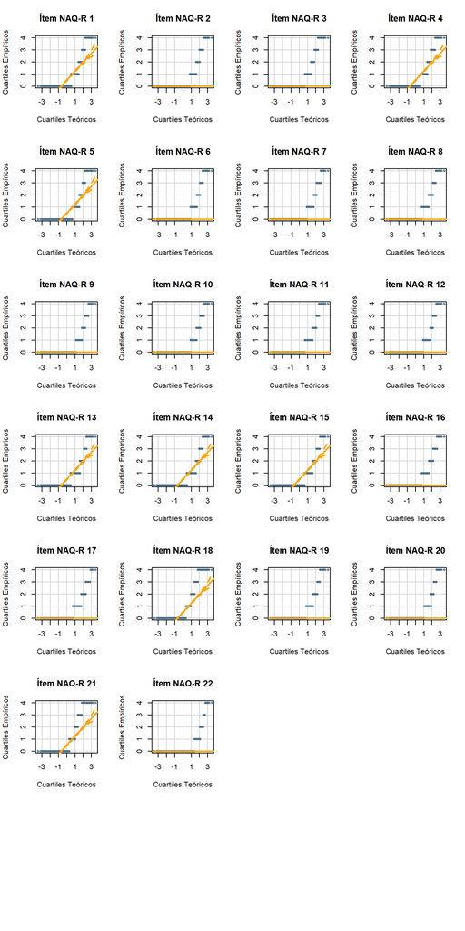

Figura S1. Gráficos Cuantil-Cuantil Ítems NAQ-R (intervalos de confianza en naranjo)

```r
par(mfrow=c(7,4))
for (k in 1:22) {
         car::qqPlot(data.frame(BD_2020_input_num)[,paste0("naq",k)], col = "skyblue4",  main = paste("Ítem NAQ-R",k),xlab="Cuartiles Teóricos", ylab="Cuartiles Empíricos",id=F, col.lines="orange")
}
```

```r
options(knitr.kable.NA = '')
MVN::mvn(BD_2020_input_num[,paste0("naq",1:22)], subset = NULL, mvnTest = "mardia", covariance = TRUE, tol = 1e-25, alpha = 0.5,
         scale = FALSE, desc = TRUE, transform = "none", R = 1000,
         univariateTest = "Lillie",
         univariatePlot = "none", multivariatePlot = "none",
         multivariateOutlierMethod = "none", bc = FALSE, bcType = "rounded",
         showOutliers = FALSE, showNewData = FALSE)$multivariateNormality%>%
  data.frame()%>%
  dplyr::mutate(across(c("Statistic","p.value"),~ifelse(grepl("NA",.),NA_real_,as.numeric(as.character(.)))))%>%
  dplyr::mutate(Statistic=sprintf("%8.2f",Statistic))%>%
  dplyr::mutate(p.value=sprintf("%5.3f",p.value))%>%
  dplyr::mutate(across(c("Statistic","p.value"),~ifelse(grepl("NA",.),"-",as.character(.))))%>%
   knitr::kable(.,format = "html", format.args = list(decimal.mark = ".", big.mark = ","),
               caption = paste0("Tabla S3a. Normalidad Multivariada NAQ-R"),
               col.names = c("Prueba","Estadistico","Valor p","Normalidad"),
align =c('l',rep('c', 101)))%>%
      kableExtra::add_footnote(c("Nota. Mardia Skewness= Asimetría Multivariante de Mardia (1970); Mardia Kurtosis= Curtosis Multivariante de Mardia (1970)"), notation = "none")%>%
  kableExtra::kable_styling(bootstrap_options = c("striped", "hover"),font_size = 10)
```

Tabla S3a. Normalidad Multivariada NAQ-R

Prueba

Estadistico

Valor p

Normalidad

Mardia Skewness

80560.92

0.000

NO

Mardia Kurtosis

718.15

0.000

NO

MVN

NO

Nota. Mardia Skewness= Asimetría Multivariante de Mardia (1970); Mardia Kurtosis= Curtosis Multivariante de Mardia (1970)

A partir de la prueba de Mardia, se puede interpretar que los ítems del NAQ no siguen una distirbución multivariada normal.

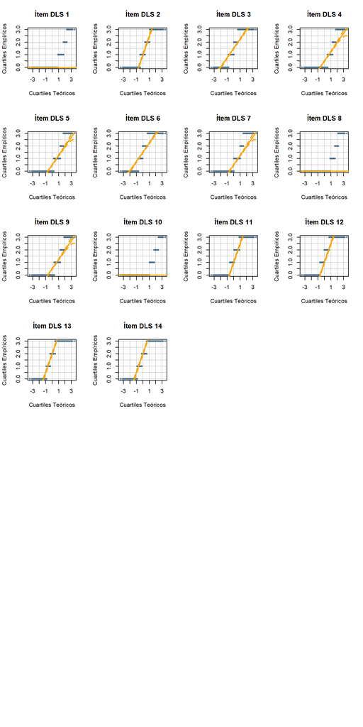

Figura S2. Gráficos Cuantil-Cuantil Ítems DLS (intervalos de confianza en naranjo)

```r
#grey(0.8)
par(mfrow=c(7,4))
for (k in 1:14) {
         car::qqPlot(data.frame(BD_2020_input_num)[,paste0("lid_des",k)], col = "skyblue4", main = paste("Ítem DLS",k),
                xlab="Cuartiles Teóricos",
                ylab="Cuartiles Empíricos",id=F, col.lines="orange")
}
```

```r
options(knitr.kable.NA = '')
MVN::mvn(BD_2020_input_num[,paste0("lid_des",1:14)], subset = NULL, mvnTest = "mardia", covariance = TRUE, tol = 1e-25, alpha = 0.5,
         scale = FALSE, desc = TRUE, transform = "none", R = 1000,
         univariateTest = "Lillie",
         univariatePlot = "none", multivariatePlot = "none",
         multivariateOutlierMethod = "none", bc = FALSE, bcType = "rounded",
         showOutliers = FALSE, showNewData = FALSE)$multivariateNormality%>%
  data.frame()%>%
  dplyr::mutate(across(c("Statistic","p.value"),~ifelse(grepl("NA",.),NA_real_,as.numeric(as.character(.)))))%>%
  dplyr::mutate(Statistic=sprintf("%8.2f",Statistic))%>%
  dplyr::mutate(p.value=sprintf("%5.3f",p.value))%>%
  dplyr::mutate(across(c("Statistic","p.value"),~ifelse(grepl("NA",.),"-",as.character(.))))%>%
   knitr::kable(.,format = "html", format.args = list(decimal.mark = ".", big.mark = ","),
               caption = paste0("Tabla S3b. Normalidad Multivariada DLS"),
               col.names = c("Prueba","Estadistico","Valor p","Normalidad"),
align =c('l',rep('c', 101)))%>%
    kableExtra::add_footnote(c("Nota. Mardia Skewness= Asimetría Multivariante de Mardia (1970); Mardia Kurtosis= Curtosis Multivariante de Mardia (1970)"), notation = "none")%>%
  kableExtra::kable_styling(bootstrap_options = c("striped", "hover"),font_size = 10)
```

Tabla S3b. Normalidad Multivariada DLS

Prueba

Estadistico

Valor p

Normalidad

Mardia Skewness

12922.77

0.000

NO

Mardia Kurtosis

107.44

0.000

NO

MVN

NO

Nota. Mardia Skewness= Asimetría Multivariante de Mardia (1970); Mardia Kurtosis= Curtosis Multivariante de Mardia (1970)

De igual forma, los ítems de DLS tampoco siguen una distribución multivariada normal.

# Factorial

## NAQ-R

```r
#especifico el modelo
mod_naqr  <-"RT =~ naq1 + naq3  +naq14 +naq16 +naq18 +naq19 +naq21
AP =~ naq2  +naq4  +naq5  +naq6  +naq7  +naq10+naq11 +naq12 +naq13 +naq15 +naq17 +naq20
AF =~ naq8  +naq9  +naq22"

mod_naqr1  <-"naq_R =~ naq1 + naq3  +naq14 +naq16 +
naq18 +naq19 +naq21+ naq2  +naq4  +naq5  +
naq6  +naq7  +naq10+naq11 +naq12 +naq13 +
naq15 +naq17 +naq20 + naq8  +naq9  +naq22"
mod_naqr2  <-"RT =~ naq1+ naq3+naq14+naq16+naq18+naq19+naq21
AP =~ naq2  +naq4  +naq5  +naq6  +naq7  +naq10+naq11 +naq12 +naq13 +naq15 +naq17 +naq20+ naq8  +naq9  +naq22"
naq_fa <- lavaan::cfa(mod_naqr, data = BD_2020_input, ordered=NAQ_R2, estimator= "WLS", warn = T)
naq_fa1f <- lavaan::cfa(mod_naqr1, data = BD_2020_input, ordered=NAQ_R2, estimator= "WLS", warn = T)
naq_fa2f <- lavaan::cfa(mod_naqr2, data = BD_2020_input, ordered=NAQ_R2, estimator= "WLS", warn = T)
```

```r
data.table(data.frame(rbind(ajusteAFC(naq_fa),ajusteAFC(naq_fa2f),ajusteAFC(naq_fa1f))),keep.rownames = T)%>%
  dplyr::mutate(rn=c("Tres Factores","Dos Factores", "Un Factor"))%>%
  dplyr::select(-Modelo)%>%
  knitr::kable(.,format = "html", format.args = list(decimal.mark = ".", big.mark = ","),
               caption = paste0("Tabla S4. Comparativo Índices de Ajuste de Modelos Propuestos NAQ-R"),
               align =c('l',rep('c', 101)),
               col.names = c("Modelo","gl","WLS X2","CMIN/df","aGFI","GFI", "RMSEA\n[IC 90%]","CFit","CFI","NNFI")) %>%
      kableExtra::row_spec(1, bold= T, color= "black", background= "white")%>%
  kableExtra::kable_styling(bootstrap_options = c("striped", "hover"),font_size = 10)
```

Tabla S4. Comparativo Índices de Ajuste de Modelos Propuestos NAQ-R

| Modelo | gl | WLS X2 | CMIN/df | aGFI | GFI | RMSEA [IC 90%] | CFit | CFI | NNFI |
| --- | --- | --- | --- | --- | --- | --- | --- | --- | --- |
| Tres Factores | 206 | 632.699 | 3.071 | 0.990 | 0.994 | 0.033[0.030-0.036] | 1.000 | 0.969 | 0.966 |
| Dos Factores | 208 | 644.997 | 3.101 | 0.990 | 0.994 | 0.033[0.030-0.036] | 1.000 | 0.969 | 0.965 |
| Un Factor | 209 | 648.069 | 3.101 | 0.990 | 0.994 | 0.033[0.030-0.036] | 1.000 | 0.969 | 0.965 |

```r
lavaan::anova(naq_fa,naq_fa2f,naq_fa1f)%>%
  data.frame()%>%
  dplyr::mutate(mod=c("Modelo de 3 factores","Modelo de 2 factores (Comparación con modelo de 3 factores)","Modelo de 2 factores (Comparación con modelo de 1 factor)"))%>%
  dplyr::select(mod, everything())%>%#Df    AIC BIC Chisq   Chisq diff  Df diff Pr(>Chisq)
  dplyr::select(-AIC,   -BIC)%>%
    dplyr::mutate(Chisq.diff=dplyr::case_when(Pr..Chisq.<.001~paste0(sprintf("%4.2f",Chisq.diff),"***"),
                    Pr..Chisq.<.01~paste0(sprintf("%4.2f",Chisq.diff),"**"),
                    Pr..Chisq.<.05~paste0(sprintf("%4.2f",Chisq.diff),"*"),
                    TRUE~paste0(sprintf("%4.2f",Chisq.diff))))%>%
  knitr::kable(.,format = "html", format.args = list(decimal.mark = ".", big.mark = ","),
               caption = paste0("Tabla S5. Comparativo Índices de Ajuste, Diferencias Chi-Cuadrado entre Modelos Anidados"),
               align =c('l',rep('c', 101)),
               col.names = c("Parámetros","gl","Chi Cuadrado","Diff. Chi Cuadrado", "Diferencias en gl","Valores p (Diferencias)"))%>%
  kableExtra::kable_styling(bootstrap_options = c("striped", "hover"),font_size = 10)
```

Tabla S5. Comparativo Índices de Ajuste, Diferencias Chi-Cuadrado entre Modelos Anidados

| Parámetros | gl | Chi Cuadrado | Diff. Chi Cuadrado | Diferencias en gl | Valores p (Diferencias) |
| --- | --- | --- | --- | --- | --- |
| Modelo de 3 factores | 206 | 632.6993 | NA |  |  |
| Modelo de 2 factores (Comparación con modelo de 3 factores) | 208 | 644.9971 | 12.30** | 2 | 0.0021358 |
| Modelo de 2 factores (Comparación con modelo de 1 factor) | 209 | 648.0695 | 3.07 | 1 | 0.0796329 |

De acuerdo a la prueba anova, el índice Chi-cuadrado es significativamente menor en el modelo de tres factores.

A continuación, se muestra el detalle del modelo de 3 factores.

```r
summary(naq_fa)
```

```
## lavaan 0.6-7 ended normally after 80 iterations
##
##   Estimator                                        WLS
##   Optimization method                           NLMINB
##   Number of free parameters                        113
##
##                                                   Used       Total
##   Number of observations                          1927        1995
##
## Model Test User Model:
##
##   Test statistic                               632.699
##   Degrees of freedom                               206
##   P-value (Chi-square)                           0.000
##
## Parameter Estimates:
##
##   Standard errors                             Standard
##   Information                                 Expected
##   Information saturated (h1) model        Unstructured
##
## Latent Variables:
##                    Estimate  Std.Err  z-value  P(>|z|)
##   RT =~
##     naq1              1.000
##     naq3              1.073    0.017   61.702    0.000
##     naq14             1.014    0.018   55.217    0.000
##     naq16             1.052    0.019   56.075    0.000
##     naq18             0.897    0.019   47.850    0.000
##     naq19             1.091    0.019   58.414    0.000
##     naq21             0.937    0.018   53.050    0.000
##   AP =~
##     naq2              1.000
##     naq4              0.965    0.013   76.530    0.000
##     naq5              0.973    0.013   75.061    0.000
##     naq6              1.016    0.012   81.843    0.000
##     naq7              1.038    0.011   94.409    0.000
##     naq10             0.998    0.013   77.720    0.000
##     naq11             0.962    0.014   70.540    0.000
##     naq12             1.040    0.011   90.648    0.000
```

[output cut: 173 more lines]

```
##     naq2              1.000
##     naq4              1.000
##     naq5              1.000
##     naq6              1.000
##     naq7              1.000
##     naq10             1.000
##     naq11             1.000
##     naq12             1.000
##     naq13             1.000
##     naq15             1.000
##     naq17             1.000
##     naq20             1.000
##     naq8              1.000
##     naq9              1.000
##     naq22             1.000
```

A continaución se presenta una Figura Scon la solución que asume tres factores.

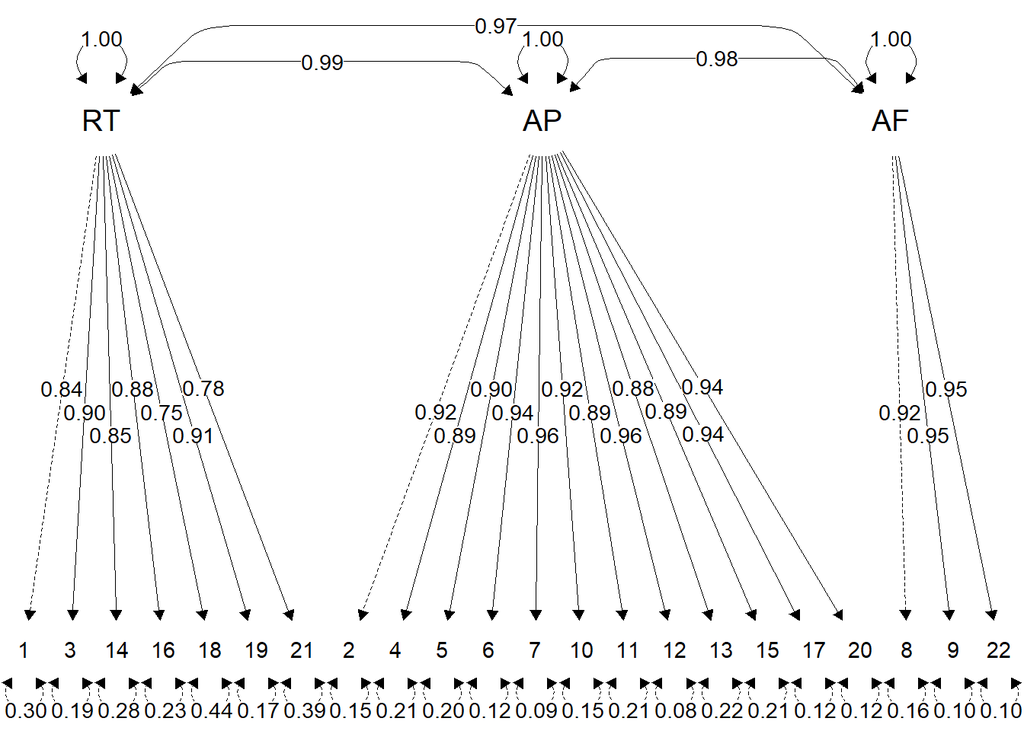

Figura S3. Cargas factoriales estandarizadas y comunalidades para NAQ-R

```r
semPlot::semPaths(naq_fa, residuals=T, what="std",label.cex=1.2, edge.label.cex=1, sizeMan=6, thresholds=F, legend=F,intercepts=FALSE,
                  curveAdjacent = TRUE,title=F, layout="tree2",fade=FALSE,edge.color="black",
                  edge.label.position=c(rep(c(0.5,0.55,0.6),7),0.5,rep(0.5,27),rep(0.5,26)),
                  sizeLat = 8,cut=1.2,curve=1.1, curvePivot=T,borders=FALSE, nCharNodes=0,
                  nCharEdges=0,optimizeLatRes=F,edge.width = 1, node.width =1, node.height= 1,
                  nodeLabels=c(paste0("",c(1,3,14,16,18,19,21,2,4,5,6,7,10,11,12,13,15,17,20,8,9,22)),"RT", "AP", "AF"),
                  mar = c(3.1, 0.5, 4.5, 0.5))
```

## DLS

Se especificaron los modelos que asumen la presencia de un factor, Liderazgos, compuesto por los 14 ítems. El siguiente modelo asume dos factores: liderazgos destructivos (ítems 3, 5, 7, 9, 1, 4, 8 y 10) y constructivos (ítems 2, 6, 11, 12, 13 y 14). El último modelo asume tres factores: liderazgo laissez-faire (ítems 3, 5, 7 y 9), autoritario (1, 4, 8 y 10) y constructivo (2, 6, 11, 12, 13 y 14) (Aasland et al. 2010).

```r
mod_lid_des_1f_inicial<-   "lid_des_CONS=~ lid_des2 + lid_des6 +lid_des11 +lid_des12+lid_des13+lid_des14+lid_des3+lid_des5+lid_des7+lid_des9+ lid_des1+lid_des4+lid_des8+lid_des10"
mod_lid_des_2f_inicial<-   "LC=~ lid_des2 + lid_des6 +lid_des11 +lid_des12+lid_des13+lid_des14
LD=~ lid_des3+lid_des5+lid_des7+lid_des9+lid_des1+lid_des4+lid_des8+lid_des10"
mod_lid_des_3f_inicial<-   "LC=~ lid_des2 + lid_des6 +lid_des11 +lid_des12+lid_des13+lid_des14
LF=~ lid_des3+lid_des5+lid_des7+lid_des9
LT=~ lid_des1+lid_des4+lid_des8+lid_des10"
```

```r
#LID_DES <- names(BD_2020_input[paste0("lid_des", 1:14)])
LID_DES<- paste0("lid_des", 1:14)
lid_des_fa_1f_inicial<- lavaan::cfa(mod_lid_des_1f_inicial, data = BD_2020_input, ordered=LID_DES, estimator= "WLS", warn = T)
lid_des_fa_2f_inicial<- lavaan::cfa(mod_lid_des_2f_inicial, data = BD_2020_input, ordered=LID_DES, estimator= "WLS", warn = T)
lid_des_fa_3f_inicial<- lavaan::cfa(mod_lid_des_3f_inicial, data = BD_2020_input, ordered=LID_DES, estimator= "WLS", warn = T)
```

A continuación, se presentan los índices de ajuste de los modelos de uno, dos y tres factores.

```r
data.table(data.frame(rbind(ajusteAFC(lid_des_fa_3f_inicial),ajusteAFC(lid_des_fa_2f_inicial),ajusteAFC(lid_des_fa_1f_inicial))),keep.rownames = T)%>%
  dplyr::mutate(rn=c("Tres Factores","Dos Factores", "Un Factor"))%>%
  dplyr::select(-Modelo)%>%
  knitr::kable(.,format = "html", format.args = list(decimal.mark = ".", big.mark = ","),
               caption = paste0("Tabla S6. Comparativo Índices de Ajuste de Modelos Propuestos DLS"),
               align =c('l',rep('c', 101)),
               col.names = c("Modelo","gl","WLS X2","CMIN/df","aGFI","GFI", "RMSEA\n[IC 90%]","CFit","CFI","NNFI")) %>%
  kableExtra::kable_styling(bootstrap_options = c("striped", "hover"),font_size = 10)
```

Tabla S6. Comparativo Índices de Ajuste de Modelos Propuestos DLS

| Modelo | gl | WLS X2 | CMIN/df | aGFI | GFI | RMSEA [IC 90%] | CFit | CFI | NNFI |
| --- | --- | --- | --- | --- | --- | --- | --- | --- | --- |
| Tres Factores | 74 | 1502.609 | 20.306 | 0.973 | 0.985 | 0.103[0.098-0.107] | 0.000 | 0.922 | 0.904 |
| Dos Factores | 76 | 1962.982 | 25.829 | 0.966 | 0.981 | 0.116[0.112-0.121] | 0.000 | 0.897 | 0.876 |
| Un Factor | 77 | 2138.680 | 27.775 | 0.963 | 0.979 | 0.121[0.116-0.125] | 0.000 | 0.887 | 0.866 |

El modelo de 3 factores especificado que asume la presencia 3 tipos de variables latentes correspondientes a los liderazgos planteados originalmente por Aasland, et al. (2010), no presenta un ajuste suficiente de acuerdo a los parámetros definidos. Igualmente, modelos que asumieron la presencia de uno o dos factores no presentan mejores índices de ajuste. Por lo mismo, se reespecifica dicho modelo conforme a índices de modificación. Estos criterios son de utilidad para orientar los parámetros a reespecificar, de la estructura factorial evaluada inicialmente.

De todas formas se presenta el detalle de la solución factorial del modelo de tres factores.

```r
summary(lid_des_fa_3f_inicial)
```

```
## lavaan 0.6-7 ended normally after 63 iterations
##
##   Estimator                                        WLS
##   Optimization method                           NLMINB
##   Number of free parameters                         59
##
##                                                   Used       Total
##   Number of observations                          1837        1995
##
## Model Test User Model:
##
##   Test statistic                              1502.609
##   Degrees of freedom                                74
##   P-value (Chi-square)                           0.000
##
## Parameter Estimates:
##
##   Standard errors                             Standard
##   Information                                 Expected
##   Information saturated (h1) model        Unstructured
##
## Latent Variables:
##                    Estimate  Std.Err  z-value  P(>|z|)
##   LC =~
##     lid_des2          1.000
##     lid_des6          1.022    0.015   68.673    0.000
##     lid_des11         1.066    0.014   76.391    0.000
##     lid_des12         1.045    0.016   67.240    0.000
##     lid_des13         1.150    0.015   77.161    0.000
##     lid_des14         1.153    0.015   79.451    0.000
##   LF =~
##     lid_des3          1.000
##     lid_des5         -0.616    0.019  -32.749    0.000
##     lid_des7         -0.548    0.019  -28.263    0.000
##     lid_des9         -0.472    0.020  -23.639    0.000
##   LT =~
##     lid_des1          1.000
##     lid_des4          1.162    0.043   27.167    0.000
##     lid_des8          1.114    0.041   27.355    0.000
##     lid_des10         1.166    0.046   25.547    0.000
```

[output cut: 95 more lines]

```
##                    Estimate  Std.Err  z-value  P(>|z|)
##     lid_des2          1.000
##     lid_des6          1.000
##     lid_des11         1.000
##     lid_des12         1.000
##     lid_des13         1.000
##     lid_des14         1.000
##     lid_des3          1.000
##     lid_des5          1.000
##     lid_des7          1.000
##     lid_des9          1.000
##     lid_des1          1.000
##     lid_des4          1.000
##     lid_des8          1.000
##     lid_des10         1.000
```

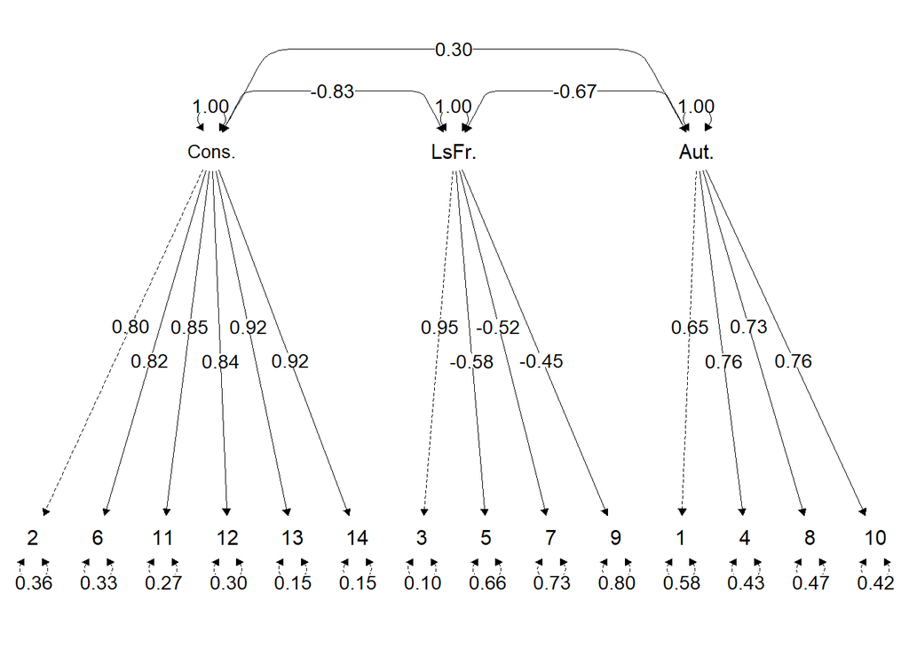

Figura S4. Cargas factoriales estandarizadas y comunalidades para DLS (solución inicial a estudiar)

```r
semPlot::semPaths(lid_des_fa_3f_inicial, residuals=T, what="std", label.cex=1.5,
                  edge.label.cex=1,fade=FALSE,
                  thresholds = F,
                  edge.label.position=c(rep(c(0.45,0.55),7),rep(0.5,19),rep(0.5,18)), #11  it, #17 #14 parámetros para las cargas
                  intercepts=F, curveAdjacent = TRUE,title=F, layout="tree3",sizeMan=5, gui = T,
                  allVars = FALSE,cut=1.1,sizeLat=5, edge.color="black",
                  curvePivot=T,borders=FALSE, edge.width = 0.5, node.width =1, node.height= 1,label.scale=T,curve = 1.5,
                  nodeLabels=c(paste0("",c(2,6,11,12,13,14,3,5,7,9,1,4,8,10)),"Cons.","LsFr.","Aut."),
                  mar = c(5.8, 0.8, 7.8, 0.8))
```

```r
                  #edge.label.position=c(rep(c(0.45,0.55),5),0.45,rep(0.5,16),rep(0.5,15)), #11  it,
#lid_des_fa_3f_inicial
```

### Reespecificación del Modelo DLS de 3 Factores

```r
cor_table <- residuals(lid_des_fa_3f_inicial, type = "standardized")$cov

cor_table[lower.tri(cor_table)] <- NA # erase the upper triangle
diag(cor_table) <- NA # erase the diagonal 0's

 knitr::kable(cor_table,digits=2,format = "html", format.args = list(decimal.mark = ".", big.mark = ","),
               caption = paste0("Tabla S7. Matriz de Residuos de Covarianzas, Modelo de Tres Factores Inicial DLS"),
               align =c('l',rep('c', 101)))%>%
kableExtra::kable_styling(bootstrap_options = c("striped", "hover"),font_size = 10) %>%
  kableExtra::scroll_box(width = "100%", height = "375px")
 #covarianzas estandarizadas residuales de los ítems, las cuales, según Fernández Aráuz (2015), pueden ser entendidas como “el número de desviaciones estándar por el cual los residuos ajustados difieren de los residuos de valor cero que estarían asociados con un modelo de ajuste perfecto” (p. 58) y, por tanto, pueden generar que se subestime o sobreestime la relación entre los indicadores. Al revisar estos valores, se encontraron valores altos (> 2,56)
```

[output not shown]

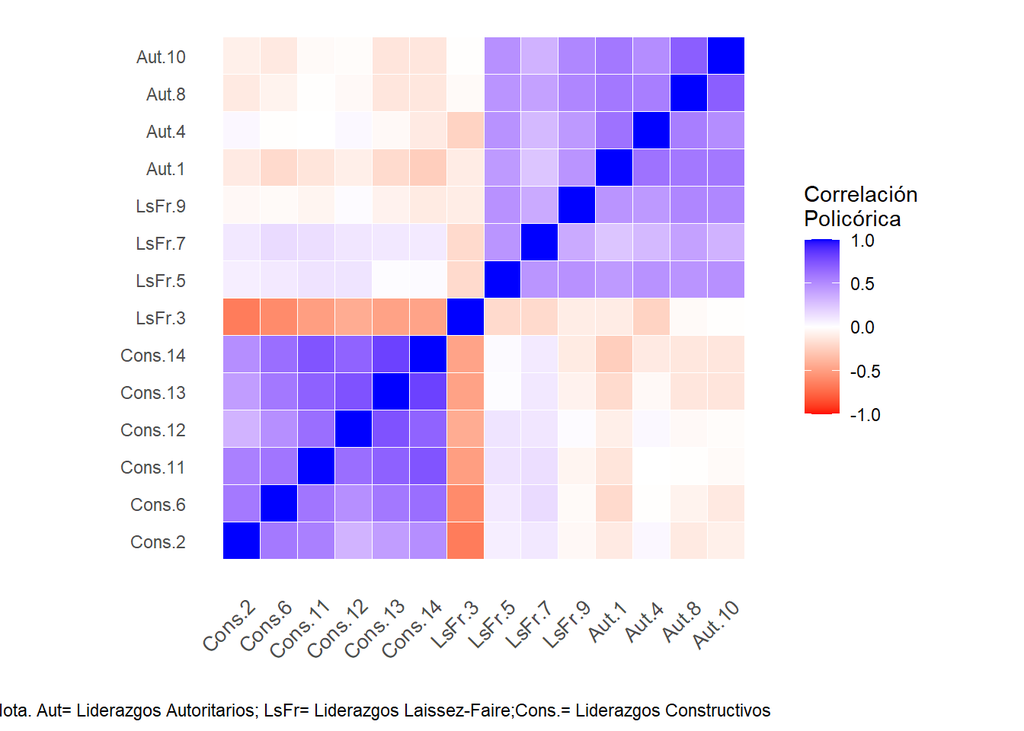

Figura S5. Matriz de correlaciones policóricas para DLS (solución inicial a estudiar)

```r
#matriz policórica
lides_policor_wgt <- reshape2::melt(as.matrix(psych::polychoric(BD_2020_input[,paste0("lid_des",c(2,6,11,12,13,14,3,5,7,9,1,4,8,10))],global=TRUE,ML=FALSE, std.err=FALSE,weight=BD_2020_input$weight,correct=.5,progress=TRUE,na.rm=TRUE, delete=TRUE)$rho))

ggheatmap_LD <- ggplot(lides_policor_wgt, aes(Var2, Var1, fill = value))+
  geom_tile(color = "white")+
  scale_fill_gradient2(low = "red", high = "blue", mid = "white",
                       midpoint = 0, limit = c(-1,1), space = "Lab",
                       name="Correlación\nPolicórica") +
  theme_minimal()+ # minimal theme
  theme(axis.text.x = element_text(angle = 45, vjust = 0.9,
                                   size = 10, hjust = .9))+
  coord_fixed()+
  scale_x_continuous(breaks = 1:14,
                     labels = c(paste0("Cons.",c(2,6,11,12,13,14)),
                                              paste0("LsFr.",c(3,5,7,9)),
                                              paste0("Aut.",c(1,4,8,10))))+
  scale_y_continuous(breaks = 1:14,
                     labels = c(paste0("Cons.",c(2,6,11,12,13,14)),
                                              paste0("LsFr.",c(3,5,7,9)),
                                              paste0("Aut.",c(1,4,8,10))))+
  ylab("")+
  xlab("")+
  theme(panel.grid.major = element_blank(), panel.grid.minor = element_blank())+
  labs(caption="Nota. Aut= Liderazgos Autoritarios; LsFr= Liderazgos Laissez-Faire;Cons.= Liderazgos Constructivos")
print(ggheatmap_LD)
```

```r
#para obtener los valores P de significación.
#lides_policor_wgt_2 <- psych::cor.ci(BD_2020_input[c(LID_DES_LC,LID_DES_LF,LID_DES_LT)],
#                  global=TRUE,ML=FALSE, std.err=FALSE,weight=BD_2020_input$weight, poly=T,
#                  correct=.5,progress=TRUE,na.rm=TRUE, delete=TRUE)$rho
#print(psych::corr.test(lides_policor_wgt_2), short=FALSE)
```

Un análisis de la matriz de correlaciones policóricas permite observar que el ítem 3 no presenta correlaciones con el resto de las variables correspondientes a Liderazgo Laissez-Faire.

Luego, se presentan los índices de modificación al modelo de tres factores. Se examinaron aquellos parámetros de modificación que presentaran un índice de modifcación (MI) mayor a 5 y cambios esperados del parámetro (Expected Parameter Change o SEPC) mayores a 0,2 (Whittaker 2012).

```r
df_mi_dls_1<-
  subset(lavaan::modindices(lid_des_fa_3f_inicial)[order(lavaan::modindices(lid_des_fa_3f_inicial)$mi, decreasing=TRUE), ], mi > 5 & abs(sepc.all)>0.2)%>%
  data.frame()%>%
  dplyr::mutate(lhs=paste0(lhs,op,rhs))%>%
  dplyr::mutate(mi=sprintf("%04.2f",mi))%>%
  dplyr::mutate(sepc.all=sprintf("%04.2f",sepc.all))%>%
  dplyr::select(lhs,mi,sepc.all)

  knitr::kable(df_mi_dls_1,format = "html", format.args = list(decimal.mark = ".", big.mark = ","),
               caption = paste0("Tabla S7. Índices de Modificación, Modelo de Tres Factores Inicial DLS"),
               align =c('l',rep('c', 101)),
               col.names = c("Relación entre variables","Índice de Modificación", "Cambio esperado del parámetro Estandarizado (SEPC)"))%>%
    kableExtra::kable_styling(bootstrap_options = c("striped", "hover"),font_size = 10) %>%
    kableExtra::row_spec(which(grepl("lid_des3",df_mi_dls_1$lhs)), bold= T, color= "white", background= "cornflowerblue")%>%
    kableExtra::row_spec(which(grepl("lid_des13",df_mi_dls_1$lhs)), bold= T, color = "#104e8b", background = "#d3d3d3")%>%
    kableExtra::row_spec(which(grepl("lid_des2",df_mi_dls_1$lhs)), bold= T, color = "darkolivegreen4", background = "darkseagreen")%>%
  kableExtra::add_footnote(c("Nota. En color, parámetros a estudiar","=~ : efecto de una variable observada en una variable latente","~~: covarianza entre los errores de dos variables observadas"),
                            notation = "none")%>%
  kableExtra::scroll_box(width = "100%", height = "375px")
```

Tabla S7. Índices de Modificación, Modelo de Tres Factores Inicial DLS

| Relación entre variables | Índice de Modificación | Cambio esperado del parámetro Estandarizado (SEPC) |
| --- | --- | --- |
| LC=~lid_des3 | 410.24 | -2.41 |
| LT=~lid_des3 | 219.20 | 1.03 |
| lid_des2~~lid_des3 | 207.45 | -1.11 |
| LF=~lid_des2 | 175.36 | -0.61 |
| LT=~lid_des9 | 150.73 | 0.49 |
| LC=~lid_des9 | 144.56 | -0.69 |
| LT=~lid_des2 | 124.53 | 0.30 |
| LF=~lid_des4 | 71.87 | -0.30 |
| lid_des5~~lid_des7 | 64.20 | 0.25 |
| LC=~lid_des4 | 61.60 | 0.20 |
| lid_des13~~lid_des14 | 51.46 | 0.44 |
| lid_des8~~lid_des10 | 49.10 | 0.44 |
| lid_des11~~lid_des13 | 45.23 | -0.27 |
| lid_des12~~lid_des13 | 42.51 | 0.30 |
| lid_des7~~lid_des1 | 41.17 | -0.27 |
| LC=~lid_des5 | 38.83 | -0.35 |
| LT=~lid_des5 | 38.59 | 0.25 |
| lid_des5~~lid_des4 | 36.16 | 0.21 |
| lid_des14~~lid_des3 | 34.64 | 0.42 |
| lid_des4~~lid_des10 | 28.46 | -0.30 |
| lid_des13~~lid_des5 | 22.61 | -0.24 |
| lid_des3~~lid_des5 | 16.76 | 0.37 |
| lid_des6~~lid_des3 | 14.33 | -0.23 |
| lid_des3~~lid_des8 | 12.54 | 0.39 |
| lid_des13~~lid_des4 | 10.97 | 0.22 |
| lid_des3~~lid_des10 | 10.33 | 0.45 |

Nota. En color, parámetros a estudiar  
=~ : efecto de una variable observada en una variable latente  
~~: covarianza entre los errores de dos variables observadas

A partir de la Tabla S7, se puede observar que una buena parte de los parámetros involucran ítems correspondientes a la escala de Liderazgo Laissez-Faire, dado que los índices más altos muestran un vínculo con él, destacando el ítem 3.

Otro ítem muy frecuente entre los índices de modificación es el ítem 2, el que mostró una importante proporción de error (36% de la varianza) al interior de la subescala de Liderazgo Constructivo, junto con una importante relación con el ítem 3 y las variables latentes Liderazgo Laissez-Faire y Liderazgo Autoritario/Tiránico. Por último, se eliminó el ítem 13 (“¿Define y explica claramente las tareas que le asigna a usted y a sus compañeros de trabajo?”) el cual mostró altos MI’s.

```r
mod_lid_des_3f_sin3<-   "LC=~ lid_des2 + lid_des6 +lid_des11 +lid_des12+lid_des13+lid_des14
LF=~ lid_des5+lid_des7+lid_des9
LT=~ lid_des1+lid_des4+lid_des8+lid_des10"
mod_lid_des_3f_sin2_3<-   "LC=~ lid_des6 +lid_des11 +lid_des12+lid_des13+lid_des14
LF=~ lid_des5+lid_des7+lid_des9
LT=~ lid_des1+lid_des4+lid_des8+lid_des10"
mod_lid_des_3f_sin2_3_13<-   "LC=~ lid_des6 +lid_des11 +lid_des12+lid_des14
LF=~ lid_des5+lid_des7+lid_des9
LT=~ lid_des1+lid_des4+lid_des8+lid_des10"
mod_lid_des_2f_sin2_3_13<-   "LC=~ lid_des6 +lid_des11 +lid_des12+lid_des14
LD=~ lid_des5+lid_des7+lid_des9+lid_des1+lid_des4+lid_des8+lid_des10"
mod_lid_des_3f_sin2_3_6<-   "LC=~ lid_des11 +lid_des12+lid_des13+lid_des14
LF=~ lid_des5+lid_des7+lid_des9
LT=~ lid_des1+lid_des4+lid_des8+lid_des10"
mod_lid_des_3f_sin2_3_9<-   "LC=~ lid_des6 +lid_des11 +lid_des12+lid_des13+lid_des14
LF=~ lid_des5+lid_des7
LT=~ lid_des1+lid_des4+lid_des8+lid_des10"
mod_lid_des_3f_sin3_13_4<-   "LC=~ lid_des2 + lid_des6 +lid_des11 +lid_des12+lid_des14
LF=~ lid_des5+lid_des7+lid_des9
LT=~ lid_des1+lid_des8+lid_des10"
```

```r
lid_des_fa_3f_sin3<- lavaan::cfa(mod_lid_des_3f_sin3, data = BD_2020_input, ordered=LID_DES[-3], estimator= "WLS", warn = T)
lid_des_fa_3f_sin2_3<- lavaan::cfa(mod_lid_des_3f_sin2_3, data = BD_2020_input, ordered=LID_DES[-c(2,3)], estimator= "WLS", warn = T)
lid_des_fa_3f_sin2_3_13<- lavaan::cfa(mod_lid_des_3f_sin2_3_13, data = BD_2020_input, ordered=LID_DES[-c(2,3,13)], estimator= "WLS", warn = T)
lid_des_fa_2f_sin2_3_13<- lavaan::cfa(mod_lid_des_2f_sin2_3_13, data = BD_2020_input, ordered=LID_DES[-c(2,3,13)], estimator= "WLS", warn = T)
lid_des_fa_3f_sin2_3_6<- lavaan::cfa(mod_lid_des_3f_sin2_3_6, data = BD_2020_input, ordered=LID_DES[-c(2,3,6)], estimator= "WLS", warn = T)
lid_des_fa_3f_sin2_3_9<- lavaan::cfa(mod_lid_des_3f_sin2_3_9, data = BD_2020_input, ordered=LID_DES[-c(2,3,9)], estimator= "WLS", warn = T)
lid_des_fa_3f_sin3_13_4<- lavaan::cfa(mod_lid_des_3f_sin3_13_4, data = BD_2020_input, ordered=LID_DES[-c(3,13,4)], estimator= "WLS", warn = T)
```

```r
t3_lid_des<-data.table(data.frame(rbind(ajusteAFC(lid_des_fa_3f_sin3),
                            ajusteAFC(lid_des_fa_3f_sin2_3),
                            ajusteAFC(lid_des_fa_2f_sin2_3_13),
                            ajusteAFC(lid_des_fa_3f_sin2_3_13),
                            ajusteAFC(lid_des_fa_3f_sin2_3_6),
                            ajusteAFC(lid_des_fa_3f_sin2_3_9),
                            ajusteAFC(lid_des_fa_3f_sin3_13_4))),keep.rownames = T)%>%
  dplyr::mutate(rn=c("Tres Factores (ítem 3 eliminado)","Tres Factores (ítem 2 y 3 eliminado)","Dos Factores (ítem 2, 3 y 13 eliminado)","Tres Factores (ítem 2, 3 y 13 eliminado)", "Tres Factores (ítem 2, 3 y 6 eliminado)", "Tres Factores (ítem 2, 3 y 9 eliminado)", "Tres Factores (ítem 3, 4 y 13 eliminado)"))%>%
  dplyr::select(-Modelo)

  knitr::kable(t3_lid_des,format = "html", format.args = list(decimal.mark = ".", big.mark = ","),
               caption = paste0("Tabla S8. Comparativo Índices de Ajuste de Modelos Propuestos DLS"),
               align =c('l',rep('c', 101)),
               col.names = c("Modelo","gl","WLS X2","CMIN/df","aGFI","GFI", "RMSEA\n[IC 90%]","CFit","CFI","NNFI")) %>%
  kableExtra::kable_styling(bootstrap_options = c("striped", "hover"),font_size = 10)%>%
  kableExtra::row_spec(4, bold= T, color= "black", background= "white")%>%
  #pack_rows("Group 2", 8, 10)
  kableExtra::pack_rows("Modelos alternativos", 5, 7, label_row_css = "background-color: #666; color: #fff;")%>%
  kableExtra::add_footnote( c(paste("Nota. Modelo seleccionado en negrita.")),
                            notation = "none")
```

Tabla S8. Comparativo Índices de Ajuste de Modelos Propuestos DLS

| Modelo | gl | WLS X2 | CMIN/df | aGFI | GFI | RMSEA [IC 90%] | CFit | CFI | NNFI |
| --- | --- | --- | --- | --- | --- | --- | --- | --- | --- |
| Tres Factores (ítem 3 eliminado) | 62 | 564.438 | 9.104 | 0.989 | 0.994 | 0.066[0.061-0.071] | 0.000 | 0.970 | 0.963 |
| Tres Factores (ítem 2 y 3 eliminado) | 51 | 406.797 | 7.976 | 0.991 | 0.995 | 0.061[0.056-0.067] | 0.000 | 0.979 | 0.972 |
| Dos Factores (ítem 2, 3 y 13 eliminado) | 43 | 338.081 | 7.862 | 0.985 | 0.993 | 0.061[0.055-0.067] | 0.001 | 0.960 | 0.949 |
| Tres Factores (ítem 2, 3 y 13 eliminado) | 41 | 268.545 | 6.550 | 0.987 | 0.994 | 0.055[0.049-0.061] | 0.099 | 0.969 | 0.959 |
| **Modelos alternativos** |  |  |  |  |  |  |  |  |  |
| Tres Factores (ítem 2, 3 y 6 eliminado) | 41 | 305.039 | 7.440 | 0.992 | 0.996 | 0.059[0.053-0.065] | 0.009 | 0.983 | 0.977 |
| Tres Factores (ítem 2, 3 y 9 eliminado) | 41 | 327.642 | 7.991 | 0.992 | 0.996 | 0.061[0.055-0.068] | 0.001 | 0.983 | 0.977 |
| Tres Factores (ítem 3, 4 y 13 eliminado) | 41 | 351.051 | 8.562 | 0.984 | 0.993 | 0.064[0.058-0.070] | 0.000 | 0.959 | 0.945 |

Nota. Modelo seleccionado en negrita.

El detalle del modelo reespecificado se presenta a continaución.

```r
summary(lid_des_fa_3f_sin2_3_13)
```

```
## lavaan 0.6-7 ended normally after 37 iterations
##
##   Estimator                                        WLS
##   Optimization method                           NLMINB
##   Number of free parameters                         47
##
##                                                   Used       Total
##   Number of observations                          1851        1995
##
## Model Test User Model:
##
##   Test statistic                               268.545
##   Degrees of freedom                                41
##   P-value (Chi-square)                           0.000
##
## Parameter Estimates:
##
##   Standard errors                             Standard
##   Information                                 Expected
##   Information saturated (h1) model        Unstructured
##
## Latent Variables:
##                    Estimate  Std.Err  z-value  P(>|z|)
##   LC =~
##     lid_des6          1.000
##     lid_des11         1.193    0.023   51.495    0.000
##     lid_des12         1.096    0.023   46.933    0.000
##     lid_des14         1.271    0.025   51.028    0.000
##   LF =~
##     lid_des5          1.000
##     lid_des7          0.776    0.034   22.860    0.000
##     lid_des9          0.924    0.034   26.786    0.000
##   LT =~
##     lid_des1          1.000
##     lid_des4          1.036    0.036   28.814    0.000
##     lid_des8          1.094    0.035   31.239    0.000
##     lid_des10         1.107    0.038   29.145    0.000
##
## Covariances:
##                    Estimate  Std.Err  z-value  P(>|z|)
```

[output cut: 74 more lines]

```
##     LT                0.555    0.031   17.800    0.000
##
## Scales y*:
##                    Estimate  Std.Err  z-value  P(>|z|)
##     lid_des6          1.000
##     lid_des11         1.000
##     lid_des12         1.000
##     lid_des14         1.000
##     lid_des5          1.000
##     lid_des7          1.000
##     lid_des9          1.000
##     lid_des1          1.000
##     lid_des4          1.000
##     lid_des8          1.000
##     lid_des10         1.000
```

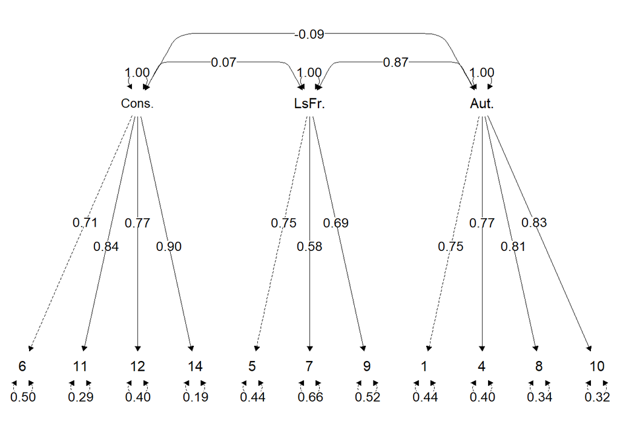

Figura S6. Cargas factoriales estandarizadas y comunalidades para DLS (solución final)

```r
semPlot::semPaths(lid_des_fa_3f_sin2_3_13, residuals=T, what="std", label.cex=1.5, edge.label.cex=1,fade=FALSE,
                  thresholds = F,
                  edge.label.position=c(rep(c(0.45,0.55),5),0.45,rep(0.5,16),rep(0.5,15)), #11  it,
                  intercepts=F, curveAdjacent = TRUE,title=F, layout="tree3",sizeMan=5, gui = T, allVars = FALSE,cut=1.1,sizeLat=5, edge.color="black",
                  curvePivot=T,borders=FALSE, edge.width = 0.5, node.width =1, node.height= 1,label.scale=T,curve = 1.5,
                  nodeLabels=c(paste0("",c(6,11,12,14,5,7,9,1,4,8,10)),"Cons.","LsFr.","Aut."),
                  mar = c(5.8, 0.8, 7.8, 0.8))
```

```r
#Finalmente, exploramos los residuos estandarizados, a fin de contrastar si mejoraron una vez eliminados los ítems 2, 3 y 13.
#
#<br>
cor_table <- residuals(lid_des_fa_3f_sin2_3_13, type = "standardized")$cov

cor_table[lower.tri(cor_table)] <- NA # erase the upper triangle
diag(cor_table) <- NA # erase the diagonal 0's

 knitr::kable(cor_table,digits=2,format = "html", format.args = list(decimal.mark = ".", big.mark = ","),
               caption = paste0("Tabla S9. Matriz de Residuos de Covarianzas, Modelo de Tres Factores Inicial DLS (ít. 2, 3 y 13 eliminados"),
               align =c('l',rep('c', 101)))%>%
kableExtra::kable_styling(bootstrap_options = c("striped", "hover"),font_size = 10) %>%
  kableExtra::scroll_box(width = "100%", height = "375px")
 #covarianzas estandarizadas residuales de los ítems, las cuales, según Fernández Aráuz (2015), pueden ser entendidas como “el número de desviaciones estándar por el cual los residuos ajustados difieren de los residuos de valor cero que estarían asociados con un modelo de ajuste perfecto” (p. 58) y, por tanto, pueden generar que se subestime o sobreestime la relación entre los indicadores. Al revisar estos valores, se encontraron valores altos (> 2,56)
```

# Confiabilidad

Para el análisis se utilizaron los coeficientes Alfa de Cronbach con las puntuaciones observadas.

## NAQ-R

```r
todos<-data.table(round(psych::alpha(BD_2020_input_num[NAQ_R2],check.keys=TRUE)$ alpha.drop,2),keep.rownames = T)
tot<-data.table(round(psych::alpha(BD_2020_input_num[NAQ_R2],check.keys=TRUE)$ total,2),keep.rownames = T)%>% dplyr::mutate(rn="Total")
#RT, AP y AF
rt<-data.table(round(psych::alpha(BD_2020_input_num[paste0("naq",c(1,3,14,16,18,19,21))],check.keys=TRUE)$ total,2),keep.rownames = T)%>% dplyr::mutate(rn="Acoso Rel. con el Trabajo")
ap<-data.table(round(psych::alpha(BD_2020_input_num[paste0("naq",c(2,4,5,6,7,10,11,12,13,15,17,20))],check.keys=TRUE)$ total,2),keep.rownames = T)%>% dplyr::mutate(rn="Acoso Dirigido a la Persona")
af<-data.table(round(psych::alpha(BD_2020_input_num[paste0("naq",c(8,9,22))],check.keys=TRUE)$ total,2),keep.rownames = T)%>% dplyr::mutate(rn="Acoso Físico")

todos%>%
  dplyr::select(rn, raw_alpha, std.alpha)%>%
  knitr::kable(.,format = "html", format.args = list(decimal.mark = ".", big.mark = ","),
               caption = paste0("Tabla S9. Índices de Confiabilidad, DLS, si se elimina un ítem (Total= ",round(psych::alpha(BD_2020_input_num[paste0("naq",1:22)],check.keys=TRUE)$total$raw_alpha,2),")"),
               align =c('l',rep('c', 101)),
               col.names = c("Parámetro","Coeficiente Alfa con las puntuaciones observadas*","Coeficiente alfa con las puntuaciones estandarizadas")) %>%
  kableExtra::kable_styling(bootstrap_options = c("striped", "hover"),font_size = 10) %>%
  kableExtra::add_footnote( c(paste("Nota. *Indicador utilizado en los análisis")),
                            notation = "none") %>%
  kableExtra::scroll_box(width = "100%", height = "375px")
```

| Parámetro | Coeficiente Alfa con las puntuaciones observadas* | Coeficiente alfa con las puntuaciones estandarizadas |
| --- | --- | --- |
| naq1 | 0.93 | 0.94 |
| naq2 | 0.93 | 0.93 |
| naq3 | 0.93 | 0.94 |
| naq4 | 0.93 | 0.94 |
| naq5 | 0.93 | 0.93 |
| naq6 | 0.93 | 0.93 |
| naq7 | 0.93 | 0.93 |
| naq8 | 0.93 | 0.93 |
| naq9 | 0.93 | 0.93 |
| naq10 | 0.93 | 0.93 |
| naq11 | 0.93 | 0.93 |
| naq12 | 0.93 | 0.93 |
| naq13 | 0.93 | 0.93 |
| naq14 | 0.93 | 0.94 |
| naq15 | 0.93 | 0.93 |
| naq16 | 0.93 | 0.94 |
| naq17 | 0.93 | 0.93 |
| naq18 | 0.93 | 0.94 |
| naq19 | 0.93 | 0.93 |
| naq20 | 0.93 | 0.93 |
| naq21 | 0.93 | 0.94 |
| naq22 | 0.93 | 0.94 |

Nota. *Indicador utilizado en los análisis

A partir de la Tabla S9, no se presentan ítems cuya eliminación signifiquen un incremento en la puntuación alfa de cronbach.

```r
rbind(tot, rt, ap, af)%>%
  dplyr::select(rn, raw_alpha, std.alpha)%>%
  knitr::kable(.,format = "html", format.args = list(decimal.mark = ".", big.mark = ","),
               caption = paste0("Tabla S10. Índices de Confiabilidad, NAQ-R Totales"),
              align =c('l',rep('c', 101)),
               col.names = c("Parámetro","Coeficiente Alfa con las puntuaciones observadas*","Coeficiente alfa con las puntuaciones estandarizadas")) %>%
  kableExtra::kable_styling(bootstrap_options = c("striped", "hover"),font_size = 10) %>%
  kableExtra::add_footnote( c(paste("Nota. *Indicador utilizado en los análisis")),
                            notation = "none")
```

Tabla S10. Índices de Confiabilidad, NAQ-R Totales

| Parámetro | Coeficiente Alfa con las puntuaciones observadas* | Coeficiente alfa con las puntuaciones estandarizadas |
| --- | --- | --- |
| Total | 0.93 | 0.94 |
| Acoso Rel. con el Trabajo | 0.80 | 0.81 |
| Acoso Dirigido a la Persona | 0.91 | 0.91 |
| Acoso Físico | 0.72 | 0.73 |

Nota. *Indicador utilizado en los análisis

Adicionalmente y como medida de sensibilidad, se computó el alfa ordinal de las pruebas y los factores, encontrándose una alta confiabilidad para la prueba NAQ-R (alpha ordinal= 0.97). Particularmente, el Acoso Relacionado con el Trabajo obtuvo una alta confiabilidad (alpha ordinal= 0.89), el Acoso Dirigido a la Persona obtuvo una alta confiabilidad (alpha ordinal= 0.95) y el Acoso Físico obtuvo una alta confiabilidad (alpha ordinal= 0.87). Ésta última incluso mostró niveles de confiabilidad bastante mayores al coeficiente alfa de cronbach para variables continuas.

```r
naq_tot_alfa_ord<-paste0(round(userfriendlyscience::scaleReliability(dat = BD_2020_input, items = paste0("naq",1:22))$output$dat$alpha.ordinal,2)," [",
round(userfriendlyscience::scaleReliability(dat = BD_2020_input, items = paste0("naq",1:22))$output$dat$alpha.ordinal.ci.lo,2),"-",
round(userfriendlyscience::scaleReliability(dat = BD_2020_input, items = paste0("naq",1:22))$output$dat$alpha.ordinal.ci.hi,2),"]")

naq_rt_alfa_ord<-paste0(round(userfriendlyscience::scaleReliability(dat = BD_2020_input, items = paste0("naq",c(1,3,14,16,18,19,21)))$output$dat$alpha.ordinal,2)," [",
round(userfriendlyscience::scaleReliability(dat = BD_2020_input, items = paste0("naq",c(1,3,14,16,18,19,21)))$output$dat$alpha.ordinal.ci.lo,2),"-"
round(userfriendlyscience::scaleReliability(dat = BD_2020_input, items = paste0("naq",c(1,3,14,16,18,19,21)))$output$dat$alpha.ordinal.ci.hi,2),"]")

naq_ap_alfa_ord<-paste0(round(userfriendlyscience::scaleReliability(dat = BD_2020_input, items = paste0("naq",c(2,4,5,6,7,10,11,12,13,15,17,20)))$output$dat$alpha.ordinal,2)," [",
round(userfriendlyscience::scaleReliability(dat = BD_2020_input, items = paste0("naq",c(2,4,5,6,7,10,11,12,13,15,17,20)))$output$dat$alpha.ordinal.ci.lo,2),"-",
round(userfriendlyscience::scaleReliability(dat = BD_2020_input, items = paste0("naq",c(2,4,5,6,7,10,11,12,13,15,17,20)))$output$dat$alpha.ordinal.ci.hi,2),"]")

naq_af_alfa_ord<-paste0(round(userfriendlyscience::scaleReliability(dat = BD_2020_input, items = paste0("naq",c(8,9,22)))$output$dat$alpha.ordinal,2)," [",
round(userfriendlyscience::scaleReliability(dat = BD_2020_input, items = paste0("naq",c(8,9,22)))$output$dat$alpha.ordinal.ci.lo,2),"-",
round(userfriendlyscience::scaleReliability(dat = BD_2020_input, items = paste0("naq",c(8,9,22)))$output$dat$alpha.ordinal.ci.hi,2),"]")

round(userfriendlyscience::scaleReliability(dat = BD_2020_input, items = paste0("naq",c(8,9,22)))$output$dat$alpha.ordinal,2)
round(userfriendlyscience::scaleReliability(dat = BD_2020_input, items = paste0("naq",c(2,4,5,6,7,10,11,12,13,15,17,20)))$output$dat$alpha.ordinal,2)
round(userfriendlyscience::scaleReliability(dat = BD_2020_input, items = paste0("naq",c(1,3,14,16,18,19,21)))$output$dat$alpha.ordinal,2)
```

[output not shown]

## DLS

```r
todos_dls_ini%>%
  dplyr::select(rn, raw_alpha, std.alpha)%>%
  knitr::kable(.,format = "html", format.args = list(decimal.mark = ".", big.mark = ","),
               caption = paste0("Tabla S11a. Índices de Confiabilidad, DLS, si se elimina un ítem (Total= ",round(psych::alpha(BD_2020_input_num[paste0("lid_des",c(1:14))],check.keys=TRUE)$total$raw_alpha,2),")"),
               align =c('l',rep('c', 101)),
               col.names = c("Parámetro","Coeficiente Alfa con las puntuaciones observadas*","Coeficiente alfa con las puntuaciones estandarizadas")) %>%
  kableExtra::kable_styling(bootstrap_options = c("striped", "hover"),font_size = 10) %>%
  kableExtra::add_footnote( c(paste("Nota. *Indicador utilizado en los análisis;\nSigno (-), Ítems de Orientación Inversa")),
                            notation = "none") %>%
  kableExtra::scroll_box(width = "100%", height = "375px")
```

[output not shown]

```r
todos_dls_ini<-data.table(round(psych::alpha(BD_2020_input_num[LID_DES],check.keys=TRUE)$ alpha.drop,2),keep.rownames = T)
tot_ini<-data.table(round(psych::alpha(BD_2020_input_num[LID_DES],check.keys=TRUE)$ total,2),keep.rownames = T)%>% dplyr::mutate(rn="Total DLS (14 ítems)")
#RT, AP y AF
lc_ini<-data.table(round(psych::alpha(BD_2020_input_num[paste0("lid_des",c(2,6,11,12,13,14))],check.keys=TRUE)$ total,2),keep.rownames = T)%>% dplyr::mutate(rn="Lid. Constructivo")
lf_ini<-data.table(round(psych::alpha(BD_2020_input_num[paste0("lid_des",c(3,5,7,9))],check.keys=TRUE)$ total,2),keep.rownames = T)%>% dplyr::mutate(rn="Lid. Laissez-Faire")
la<-data.table(round(psych::alpha(BD_2020_input_num[paste0("lid_des",c(1,4,8,10))],check.keys=TRUE)$ total,2),keep.rownames = T)%>% dplyr::mutate(rn="Lid. Autoritario")

lc_final<-data.table(round(psych::alpha(BD_2020_input_num[paste0("lid_des",c(6,11,12,14))],check.keys=TRUE)$ total,2),keep.rownames = T)%>% dplyr::mutate(rn="Lid. Constructivo (sin ítem 2 y 13)")
lf_final<-data.table(round(psych::alpha(BD_2020_input_num[paste0("lid_des",c(5,7,9))],check.keys=TRUE)$ total,2),keep.rownames = T)%>% dplyr::mutate(rn="Lid. Laissez-Faire (sin ítem 3)")

dls_sin3<-data.table(round(psych::alpha(BD_2020_input_num[paste0("lid_des",c(5,7,9,1,4,8,10))],check.keys=TRUE)$ total,2),keep.rownames = T)%>% dplyr::mutate(rn="Lid. Destructivos (sin ítem 3)")

todos_dls_ini<-data.table(round(psych::alpha(BD_2020_input_num[paste0("lid_des",1:14)],check.keys=TRUE)$ alpha.drop,2),keep.rownames = T)
todos_dls_final<-data.table(round(psych::alpha(BD_2020_input_num[paste0("lid_des",c(1,4,8,10,5,7,9,6,11,12,14))],check.keys=TRUE)$ alpha.drop,2),keep.rownames = T)

tot_final<-data.table(round(psych::alpha(BD_2020_input_num[paste0("lid_des",c(1,4,8,10,5,7,9,6,11,12,14))],check.keys=TRUE)$ total,2),keep.rownames = T)%>% dplyr::mutate(rn="Total DLS (Sin ítems 2,3 y 13)")

todos_dls_final%>%
  dplyr::select(rn, raw_alpha, std.alpha)%>%
  knitr::kable(.,format = "html", format.args = list(decimal.mark = ".", big.mark = ","),
               caption = paste0("Tabla S11. Índices de Confiabilidad, DLS (sin ítems 2,3 y 13), si se elimina un ítem (Total= ",round(psych::alpha(BD_2020_input_num[paste0("lid_des",c(1,4,8,10,5,7,9,6,11,12,14))],check.keys=TRUE)$total$raw_alpha,2),")"),
               align =c('l',rep('c', 101)),
               col.names = c("Parámetro","Coeficiente Alfa con las puntuaciones observadas*","Coeficiente alfa con las puntuaciones estandarizadas")) %>%
  kableExtra::kable_styling(bootstrap_options = c("striped", "hover"),font_size = 10) %>%
  kableExtra::add_footnote( c(paste("Nota. *Indicador utilizado en los análisis;\nSigno (-), Ítems de Orientación Inversa")),
                            notation = "none") %>%
  kableExtra::scroll_box(width = "100%", height = "375px")
```

Tabla S11. Índices de Confiabilidad, DLS (sin ítems 2,3 y 13), si se elimina un ítem (Total= 0.69)

| Parámetro | Coeficiente Alfa con las puntuaciones observadas* | Coeficiente alfa con las puntuaciones estandarizadas |
| --- | --- | --- |
| lid_des1 | 0.67 | 0.68 |
| lid_des4 | 0.68 | 0.69 |
| lid_des8 | 0.67 | 0.68 |
| lid_des10 | 0.68 | 0.69 |
| lid_des5 | 0.68 | 0.70 |
| lid_des7 | 0.71 | 0.72 |
| lid_des9 | 0.67 | 0.69 |
| lid_des6- | 0.67 | 0.71 |
| lid_des11- | 0.65 | 0.70 |
| lid_des12- | 0.67 | 0.71 |
| lid_des14- | 0.63 | 0.69 |

Nota. *Indicador utilizado en los análisis; Signo (-), Ítems de Orientación Inversa

```r
rbind(tot_ini, lc_ini, lf_ini,la, lc_final, lf_final, dls_sin3,tot_final)%>%
  dplyr::select(rn, raw_alpha, std.alpha)%>%
  knitr::kable(.,format = "html", format.args = list(decimal.mark = ".", big.mark = ","),
               caption = paste0("Tabla S12. Índices de Confiabilidad, DLS Totales"),
              align =c('l',rep('c', 101)),
               col.names = c("Parámetro","Coeficiente Alfa con las puntuaciones observadas*","Coeficiente alfa con las puntuaciones estandarizadas")) %>%
  kableExtra::kable_styling(bootstrap_options = c("striped", "hover"),font_size = 10) %>%
  kableExtra::add_footnote( c(paste("Nota. *Indicador utilizado en los análisis")),
                            notation = "none")
```

Tabla S12. Índices de Confiabilidad, DLS Totales

| Parámetro | Coeficiente Alfa con las puntuaciones observadas* | Coeficiente alfa con las puntuaciones estandarizadas |
| --- | --- | --- |
| Total DLS (14 ítems) | 0.76 | 0.69 |
| Lid. Constructivo | 0.87 | 0.87 |
| Lid. Laissez-Faire | 0.50 | 0.53 |
| Lid. Autoritario | 0.70 | 0.72 |
| Lid. Constructivo (sin ítem 2 y 13) | 0.83 | 0.83 |
| Lid. Laissez-Faire (sin ítem 3) | 0.58 | 0.59 |
| Lid. Destructivos (sin ítem 3) | 0.75 | 0.77 |
| Total DLS (Sin ítems 2,3 y 13) | 0.69 | 0.72 |

Nota. *Indicador utilizado en los análisis

Adicionalmente y como medida de sensibilidad, se computó el alfa ordinal de las pruebas y los factores, encontrándose una alta confiabilidad para la prueba DLS (alpha ordinal= 0.78). Particularmente, el Lid. Constructivo obtuvo una alta confiabilidad (alpha ordinal= 0.87), el Lid. Autoritario obtuvo una alta confiabilidad (alpha ordinal= 0.85) y el Lid. Laissez-Faire obtuvo una alta confiabilidad (alpha ordinal= 0.71). Ésta última incluso mostró niveles de confiabilidad bastante mayores al coeficiente alfa de cronbach para variables continuas.

# Descripción de Variables Seleccionadas y Recodificadas

**En primer lugar, se generaron las variables de suma de puntajes dicotomizados, suma de puntajes brutos, entre otras**.

```r
#_#_#_#_#_#_#_#_#_#_#_#_#_#_#_#_#_#_#_#_#_#_#_#_#_#_#_#_#_#_#_#_#_#_#_#_#_#_#_#_#_#_#_#_#_#_#_#_#_#_#_#_#_#_#_#_#_#_#_#_#_#_#_#_#_#_#_#_#_
#_#_#_#_#_#_#_#_#_#_#_#_#_#_#_#_#_#_#_#_#_#_#_#_#_#_#_#_#_#_#_#_#_#_#_#_#_#_#_#_#_#_#_#_#_#_#_#_#_#_#_#_#_#_#_#_#_#_#_#_#_#_#_#_#_#_#_#_#_
#_#_#_#_#_#_#_#_#_#_#_#_#_#_#_#_#_#_#_#_#_#_#_Definir Postestratificación#_#_#_#_#_#_#_#_#_#_#_#_#_#_#_#_#_#_#_#_#_#_#_

BD_2020_input%>%
dplyr::mutate_at(.vars= vars(naq1, naq2, naq3,naq4, naq5, naq6, naq7, naq8, naq9, naq10, naq11, naq12, naq13, naq14, naq15, naq16, naq17, naq18, naq19, naq20, naq21, naq22),.funs = ~as.numeric(.)-1)%>%
  dplyr::mutate_at(.vars= vars(lid_des1, lid_des2, lid_des3,lid_des4, lid_des5, lid_des6, lid_des7, lid_des8, lid_des9, lid_des10, lid_des11, lid_des12, lid_des13, lid_des14),.funs = ~as.numeric(.)-1)%>%

  dplyr::mutate(lc2 = rowSums(select(., .dots = paste0("lid_des",c(6,11,12,14))),na.rm=T))%>%
  dplyr::mutate(lf2 = rowSums(select(., .dots = paste0("lid_des",c(5,7,9))),na.rm=T))%>%
  dplyr::mutate(la = rowSums(select(., .dots = paste0("lid_des",c(1,4,8,10))),na.rm=T))%>%
  dplyr::mutate(lid_des_sum = rowSums(select(., .dots = paste0("lid_des",c(5,7,9,1,4,8,10))),na.rm=T))%>%

  dplyr::mutate(across(paste0("naq",1:22), ~car::recode(.,"3:4=1;0:2=0"),.names="{col}_rec"))%>%
  dplyr::mutate(across(paste0("lid_des",c(1,4,5,6,7,8,9,10,11,12,14)), ~car::recode(.,"2:3=1;0:1=0"),.names="{col}_rec"))%>%

  dplyr::mutate(naq_dic = rowSums(select(., .dots = paste0("naq",1:22,"_rec")),na.rm=T))%>%
  dplyr::mutate(naq_dic_logit = car::recode(naq_dic,"0=0;1=1;2:hi=2"))%>%
  dplyr::mutate(naq_dic_autocat = dplyr::case_when(autonaq==2 & naq_dic_logit==2~2,
                                                   autonaq==2 & naq_dic_logit<2~1,
                                                   TRUE~0))%>%
  dplyr::mutate(naq_dic_autocat = as.factor(naq_dic_autocat))%>%
  dplyr::mutate(naq_sum_cuartil = car::recode(naq_sum,"0:0=0;1:4=1;5:10=2;11:hi=3"))%>%

  dplyr::mutate(lc_rec = rowSums(select(., .dots = paste0("lid_des",c(6,11,12,14),"_rec")),na.rm=T))%>%
  dplyr::mutate(lc_rec = car::recode(lc_rec,"4:hi=4"))%>%
  dplyr::mutate(lc_rec_logit = car::recode(lc_rec,"0=2;1=1;2:hi=0"))%>%

  dplyr::mutate(lid_des_dic = rowSums(select(., .dots = paste0("lid_des",c(5,7,9,1,4,8,10),"_rec")),na.rm=T))%>%
  dplyr::mutate(lid_des_dic = car::recode(lid_des_dic,"4:7=4"))%>% #ojo, esto no estaba tan claro en stata
  dplyr::mutate(lid_des_sum_cuartil = car::recode(lid_des_sum,"0=0;1:2=1;3:4=2;5:hi=3"))%>%
  dplyr::mutate(lid_des_dic_logit = car::recode(lid_des_dic,"0=0;1=1;2:hi=2"))%>%

  dplyr::mutate(lf_dic = rowSums(select(., .dots = paste0("lid_des",c(5,7,9),"_rec")),na.rm=T))%>%#,1,4,8,10
  dplyr::mutate(lf_dic = car::recode(lf_dic,"4:7=4"))%>% #ojo, esto no estaba tan claro en stata

  dplyr::mutate(la_dic = rowSums(select(., .dots = paste0("lid_des",c(1,4,8,10),"_rec")),na.rm=T))%>%#,
  dplyr::mutate(la_dic = car::recode(la_dic,"4:7=4"))%>% #ojo, esto no estaba tan claro en stata

  dplyr::mutate(k2_elevado_num = ifelse(as.numeric(k2_elevado)==2,1,0))%>%

dplyr::mutate_at(.vars= vars(naq1, naq2, naq3,naq4, naq5, naq6, naq7, naq8, naq9, naq10, naq11, naq12, naq13, naq14, naq15, naq16, naq17, naq18, naq19, naq20, naq21, naq22),.funs = ~factor(.))%>%
  dplyr::mutate_at(.vars= vars(lid_des1, lid_des2, lid_des3,lid_des4, lid_des5, lid_des6, lid_des7, lid_des8, lid_des9, lid_des10, lid_des11, lid_des12, lid_des13, lid_des14),.funs = ~factor(.))%>%
  dplyr::mutate_at(.vars= vars(lc_rec_logit, naq_dic_logit, lid_des_dic_logit, naq_sum_cuartil, lid_des_sum_cuartil),.funs = ~factor(.+1))%>%
 #janitor::tabyl(la2,la_rec)
  assign("BD_2020_input",., envir = .GlobalEnv)

invisible(
 c("lf_rec_logit", "la_rec_logit", "lc_rec_logit",
               "naq_dic_logit", "lid_des_dic_logit",
               "naq_sum_cuartil", "lid_des_sum_cuartil")
)
#_#_#_#_#_#_#_#_#_#_#_#_#_#_#_#_#_#_#_#_#_#_#_#_#_#_#_#_#_#_#_#_#_#_#_#_#_#_#_#_#_#_#_#_#_#_#_#_#_#_#_#_#_#_#_#_#_#_#_#_#_#_#_#_#_#_#_#_#_
#Se hace numerica la variable
#BD_2020_input$k2_elevado_num <- as.numeric(BD_2020_input$k2_elevado == "2")

dsgn_BD_05_02 <- survey::svydesign(ids = ~1, data = BD_2020_input, weights = ~weight)

dsgn_mujer<- subset(BD_2020_input,mujer==1)
dsgn_hombre<- subset(BD_2020_input,mujer==0)
#_#_#_#_#_#_#_#_#_#_#_#_#_#_#_#_#_#_#_#_#_#_#_#_#_#_#_#_#_#_#_#_#_#_#_#_#_#_#_#_#_#_#_#_#_#_#_#_#_#_#_#_#_#_#_#_#_#_#_#_#_#_#_#_#_#_#_#_#_

BD_2020_input%>%
dplyr::mutate_at(.vars= vars(naq1, naq2, naq3,naq4, naq5, naq6, naq7, naq8, naq9, naq10, naq11, naq12, naq13, naq14, naq15, naq16, naq17, naq18, naq19, naq20, naq21, naq22),.funs = ~as.numeric(.)-1)%>%
  dplyr::mutate_at(.vars= vars(lid_des1, lid_des2, lid_des3,lid_des4, lid_des5, lid_des6, lid_des7, lid_des8, lid_des9, lid_des10, lid_des11, lid_des12, lid_des13, lid_des14),.funs = ~as.numeric(.)-1)%>%
    dplyr::mutate_at(.vars= vars(a47_top_1, a47_top_2, a47_top_3,a47_top_4, a47_top_5, a47_top_6),.funs = ~as.numeric(.)-1)%>%
  assign("BD_2020_input_num",., envir = .GlobalEnv)
#_#_#_#_#_#_#_#_#_#_#_#_#_#_#_#_#_#_#_#_#_#_#_#_#_#_#_#_#_#_#_#_#_#_#_#_#_#_#_#_#_#_#_#_#_#_#_#_#_#_#_#_#_#_#_#_#_#_#_#_#_#_#_#_#_#_#_#_#_
#_#_#_#_#_#_#_#_#_#_#_#_#_#_#_#_#_#_#_#_#_#_#_#_#_#_#_#_#_#_#_#_#_#_#_#_#_#_#_#_#_#_#_#_#_#_#_#_#_#_#_#_#_#_#_#_#_#_#_#_#_#_#_#_#_#_#_#_#_

n<- c("naq_sum", "naq_r_ap_sum", "naq_r_rt_sum", "naq_r_af_sum", "lc2","la", "lf2", "lid_des_sum", "k6_2")
desc<-data.frame()
for (i in c("naq_sum", "naq_r_ap_sum", "naq_r_rt_sum",
            "naq_r_af_sum", "lc2","la", "lf2",
            "lid_des_sum", "k6_2")) {
  dat<- data.frame("M (DE)"= paste0(round(unlist(svymean(as.formula(paste0("~",i)),dsgn_BD_05_02,na.rm=T))[1],2)," (",
                                                         sprintf("%4.2f",round(Weighted.Desc.Stat::w.sd(BD_2020_input[i], BD_2020_input$weight),2)),")")                                        )
  desc<- rbind(desc, dat)
}
desc<-
desc%>%
  dplyr::mutate(Variable=c("Suma de puntajes brutos NAQ-R",
                      "Suma de puntajes brutos Acoso dirigido a la Persona",
                      "Suma de puntajes brutos Rel. con el Trabajo",
                      "Suma de puntajes brutos Acoso Físico",
                      "Suma de puntajes brutos Lid. Constructivo (ít. 6,11,12 & 14)",
                      "Suma de puntajes brutos Lid. Autoritario (ít. 1,4,8 & 10)",
                      "Suma de puntajes brutos Lid. Laissez-Faire (ít. 5,7 & 9)",
                      "Suma de puntajes brutos Lid. Destructivos (ít. 5,7,9,1,4,8 & 10)",
                      "Suma de puntajes brutos Distrés Psicológico"))%>%
  dplyr::select(Variable,everything())

#pearson
set.seed(123)
cor_wtd<-svycor(~naq_sum+ naq_r_ap_sum+ naq_r_rt_sum+ naq_r_af_sum+ lc2+la+ lf2+ lid_des_sum+ k6_2
, design = dsgn_BD_05_02, digits = 2, sig.stats = TRUE, bootn = 10000, mean1 = TRUE)

cor_wtd_sig<-
data.frame(cbind(cor=data.table(round(matrix(cor_wtd$cors),2)),
p=data.table(matrix(cor_wtd$p.values))))%>%
  dplyr::rename("cor"="cor.V1","p"="p.V1")%>%
  dplyr::mutate(cor=dplyr::case_when(p<.001~paste0(sprintf("%4.2f",cor),"***"),
                    p<.01~paste0(sprintf("%4.2f",cor),"**"),
                    p<.05~paste0(sprintf("%4.2f",cor),"*"),
                    TRUE~paste0(sprintf("%4.2f",cor))))%>%
  dplyr::mutate(cor=ifelse(grepl("1.00",cor),"",cor))%>%
  dplyr::select(-p)

pearson<-
data.frame(Vars=cbind(c("naq_sum", "naq_r_ap_sum", "naq_r_rt_sum", "naq_r_af_sum", "lc2","la", "lf2", "lid_des_sum", "k6_2"),
      `1`=cor_wtd_sig[1:length(n),],
      `2`=cor_wtd_sig[(length(n)*1)+1:(length(n)*1),],
      `3`=cor_wtd_sig[(length(n)*2)+1:(length(n)*1),],
      `4`=cor_wtd_sig[(length(n)*3)+1:(length(n)*1),],
      `5`=cor_wtd_sig[(length(n)*4)+1:(length(n)*1),],
      `6`=cor_wtd_sig[(length(n)*5)+1:(length(n)*1),],
      `7`=cor_wtd_sig[(length(n)*6)+1:(length(n)*1),],
      `8`=cor_wtd_sig[(length(n)*7)+1:(length(n)*1),],
      `9`=cor_wtd_sig[(length(n)*8)+1:(length(n)*1),]))

alfas<-c(as.numeric(round(psych::alpha(BD_2020_input_num[paste0("naq",1:22)],check.keys=TRUE)$total$raw_alpha,2)),
      as.numeric(round(psych::alpha(BD_2020_input_num[paste0("naq",c(2,4,5,6,7,10,11,12,13,15,17,20))],check.keys=TRUE)$total$raw_alpha,2)),
      as.numeric(round(psych::alpha(BD_2020_input_num[paste0("naq",c(1,3,14,16,18,19,21))],check.keys=TRUE)$total$raw_alpha,2)),
      as.numeric(round(psych::alpha(BD_2020_input_num[paste0("naq",c(8,9,22))],check.keys=TRUE)$total$raw_alpha,2)),
      as.numeric(round(psych::alpha(BD_2020_input_num[paste0("lid_des",c(6,11,12,14))],check.keys=TRUE)$total$raw_alpha,2)),
      as.numeric(round(psych::alpha(BD_2020_input_num[paste0("lid_des",c(1,4,8,10))],check.keys=TRUE)$total$raw_alpha,2)),
      as.numeric(round(psych::alpha(BD_2020_input_num[paste0("lid_des",c(5,7,9))],check.keys=TRUE)$total$raw_alpha,2)),
      as.numeric(round(psych::alpha(BD_2020_input_num[paste0("lid_des",c(5,7,9,1,4,8,10))],check.keys=TRUE)$total$raw_alpha,2)),
      as.numeric(round(psych::alpha(BD_2020_input_num[paste0("a47_top_",1:6)],check.keys=TRUE)$total$raw_alpha,2))
                 )

for (i in (1:length(alfas))){
      pearson[i,colnames(pearson)[2:length(colnames(pearson))][i]]<-sprintf("%4.2f",alfas[i])
}

data.frame(cbind(desc,pearson[-1]))%>%
  dplyr::select_all(~gsub("^Vars", "", .))%>%
  knitr::kable(.,format = "html", format.args = list(decimal.mark = ",", big.mark = "."),
               caption = paste0("Tabla S13. Resumen de Variables Seleccionadas, Suma de Ítems (Ponderada)"),
               col.names = c("Variable","M (DE)",  paste0(1:9)))%>%
      kableExtra::add_footnote(c("Nota. Alfa de cronbach en diagonal"),
                            notation = "none")%>%
  kableExtra::kable_styling(bootstrap_options = c("striped", "hover"),font_size = 10)%>%
  kableExtra::scroll_box(width = "100%", height = "375px")
```

Tabla S13. Resumen de Variables Seleccionadas, Suma de Ítems (Ponderada)

| Variable | M (DE) | 1 | 2 | 3 | 4 | 5 | 6 | 7 | 8 | 9 |
| --- | --- | --- | --- | --- | --- | --- | --- | --- | --- | --- |
| Suma de puntajes brutos NAQ-R | 7.37 (9.83) | 0.93 | 0.96*** | 0.90*** | 0.79*** | -0.14*** | 0.57*** | 0.35*** | 0.53*** | 0.41*** |
| Suma de puntajes brutos Acoso dirigido a la Persona | 3.66 (5.56) | 0.96*** | 0.91 | 0.76*** | 0.77*** | -0.14*** | 0.54*** | 0.31*** | 0.49*** | 0.38*** |
| Suma de puntajes brutos Rel. con el Trabajo | 3.09 (3.81) | 0.90*** | 0.76*** | 0.80 | 0.57*** | -0.12*** | 0.52*** | 0.37*** | 0.51*** | 0.41*** |
| Suma de puntajes brutos Acoso Físico | 0.62 (1.33) | 0.79*** | 0.77*** | 0.57*** | 0.72 | -0.10*** | 0.45*** | 0.22*** | 0.39*** | 0.27*** |
| Suma de puntajes brutos Lid. Constructivo (ít. 6,11,12 & 14) | 5.98 (3.56) | -0.14*** | -0.14*** | -0.12*** | -0.10*** | 0.83 | -0.06** | 0.09*** | 0.01 | -0.08** |
| Suma de puntajes brutos Lid. Autoritario (ít. 1,4,8 & 10) | 1.16 (1.82) | 0.57*** | 0.54*** | 0.52*** | 0.45*** | -0.06** | 0.70 | 0.51*** | 0.87*** | 0.36*** |
| Suma de puntajes brutos Lid. Laissez-Faire (ít. 5,7 & 9) | 1.74 (1.80) | 0.35*** | 0.31*** | 0.37*** | 0.22*** | 0.09*** | 0.51*** | 0.58 | 0.87*** | 0.27*** |
| Suma de puntajes brutos Lid. Destructivos (ít. 5,7,9,1,4,8 & 10) | 2.89 (3.15) | 0.53*** | 0.49*** | 0.51*** | 0.39*** | 0.01 | 0.87*** | 0.87*** | 0.75 | 0.37*** |
| Suma de puntajes brutos Distrés Psicológico | 2.68 (3.94) | 0.41*** | 0.38*** | 0.41*** | 0.27*** | -0.08** | 0.36*** | 0.27*** | 0.37*** | 0.85 |

Nota. Alfa de cronbach en diagonal

Usando el criterio Leymann (1990), resultó más prevalente el Lid. Constructivo (73%), seguido por Laissez-Faire (26%), y Autoritario (16%). Usando el criterio estricto propuesto por Mikkelsen & Einarsen (2001), el porcentaje de trabajadores(as) que reportan acoso es de 10%, mientras que quienes se identifican como acosados una vez presentada una definición de acoso laboral es de 6%. Por último, quienes se identifican como acosados y a la vez dos o más conductas de acoso es de 3%.

# Asociaciones con Distrés (Razón de Prevalencia)

```r
# CREA LA VARIABLE CON EL AJUSTE DEL MODELO CRUDO
options(knitr.kable.NA = '')
PRraw<-data.table()
for(scale in  c("k2_elevado_num")){
  for(var in c("naq_dic_logit",
                "lc_rec_logit", "lid_des_dic_logit",
               "naq_sum_cuartil", "lid_des_sum_cuartil","naq_dic_autocat")){
    # dynamically generate formula
    fmla <- as.formula(paste0(scale, " ~ ", factor(var)))

    # fit glm model
    assign(paste0("svyglm_",as.character(scale),"_",as.character(var)), svyglm(fmla, design=dsgn_BD_05_02, family=quasipoisson(link=log)))
    fit <- svyglm(fmla, design=dsgn_BD_05_02, family=quasipoisson(link=log))
    #print(round(Epi::ci.lin(fit, Exp=T),3))
    PRraw<- rbind(PRraw,paste0("svyglm2_",as.character(scale),"_",as.character(var)),data.table(data.table(round(Epi::ci.lin(fit, Exp=T),3),keep.rownames = T)), fill=T)
  }
}
PRraw_mod<-
PRraw%>%
  dplyr::rename("Modelo"="x","Categoría"="rn")%>%
    dplyr::mutate(Modelo=dplyr::case_when(grepl("lf_rec",Modelo)~"Suma dicotomizada de Liderazgos Laissez-Faire",
                                        grepl("la_rec",Modelo)~"Suma dicotomizada de Liderazgos Autoritarios",
                                        grepl("lc_rec",Modelo)~"Suma dicotomizada de Liderazgos Constructivos",
                                        grepl("naq_dic_logit",Modelo)~"Suma dicotomizada de Conductas Negativas",
                                        grepl("lid_des_dic",Modelo)~"Suma dicotomizada de Liderazgos Destructivos",
                                        grepl("naq_sum_cuartil",Modelo)~"Suma de puntajes brutos de Conductas Negativas (en cuartiles)",
                                        grepl("lid_des_sum_cuartil",Modelo)~"Suma de puntajes brutos de Conductas Negativas (en cuartiles)",
                                        grepl("naq_dic_autocat",Modelo)~"Combinación de Autodefinición y Reporte Conductas Negativas",
                                        TRUE~Modelo))%>%
  data.frame()%>%
  dplyr::filter(!grepl("(Intercept)",Categoría))%>%
  dplyr::mutate(Categoría=dplyr::case_when(grepl("lf_rec_logit2",Categoría)~"1 conducta",
                                           grepl("lf_rec_logit3",Categoría)~"2 o más",
                                           grepl("la_rec_logit2",Categoría)~"1 conducta",
                                           grepl("la_rec_logit3",Categoría)~"2 o más",
                                           grepl("lc_rec_logit2",Categoría)~"1 conducta",
                                           grepl("lc_rec_logit3",Categoría)~"Ausencia conductas",
                                           grepl("naq_dic_logit2",Categoría)~"1 conducta",
                                           grepl("naq_dic_logit3",Categoría)~"2 o más",
                                           grepl("lid_des_dic_logit2",Categoría)~"1 conducta",
                                           grepl("lid_des_dic_logit3",Categoría)~"2 o más",
                                           grepl("naq_sum_cuartil2",Categoría)~"1-4 puntos",
                                           grepl("naq_sum_cuartil3",Categoría)~"5-10 puntos",
                                           grepl("naq_sum_cuartil4",Categoría)~"11 o más",
                                           grepl("lid_des_sum_cuartil2",Categoría)~"1-2 puntos",
                                           grepl("lid_des_sum_cuartil3",Categoría)~"3-4 puntos",
                                           grepl("lid_des_sum_cuartil4",Categoría)~"5 o más",
                                           grepl("naq_dic_autocat1",Categoría)~"Autodefinición",
                                           grepl("naq_dic_autocat2",Categoría)~"Autodefinición y 2 o más conductas"))%>%
  dplyr::mutate(`exp.Est..`=sprintf("%04.2f",`exp.Est..`))%>%
  dplyr::mutate(`exp.Est..`= ifelse(grepl("NA",`exp.Est..`),NA_character_,`exp.Est..`))%>%
  dplyr::mutate(PRraw=`exp.Est..`)%>%
  dplyr::mutate(PRraw=dplyr::case_when(P<.001~paste0(PRraw,"***"),P<.01~paste0(PRraw,"**"),P<.05~paste0(PRraw,"*"),TRUE~PRraw))%>%
  dplyr::mutate(`X2.5.`= sprintf("%04.2f",`X2.5.`))%>%
  dplyr::mutate(`X97.5.`=sprintf("%04.2f",`X97.5.`))%>%
  dplyr::mutate("95% IC"=paste0("[",`X2.5.`,"-",`X97.5.`,"]"))%>%
  dplyr::mutate("95% IC"= ifelse(grepl("NA]",`95% IC`),NA_character_,`95% IC`))%>%
  dplyr::select(Modelo,Categoría,PRraw, "95% IC")
```

```r
# CREA LA VARIABLE CON EL AJUSTE DEL MODELO, MAS VAR. GENERO
PR1<-data.table()
for(scale in  c("k2_elevado_num")){
for(var in c("naq_dic_logit",
                "lc_rec_logit", "lid_des_dic_logit",
               "naq_sum_cuartil", "lid_des_sum_cuartil","naq_dic_autocat")){
    # dynamically generate formula
    fmla <- as.formula(paste0(scale, " ~ ", factor(var), "+ mujer + climasex"))

    # fit glm model
    assign(paste0("svyglm2_",as.character(scale),"_",as.character(var)), svyglm(fmla, design=dsgn_BD_05_02, family=quasipoisson(link=log)))
    fit <- svyglm(fmla, design=dsgn_BD_05_02, family=quasipoisson(link=log))
    #print(round(Epi::ci.lin(fit, Exp=T),3))
    PR1<- rbind(PR1,paste0("svyglm2_",as.character(scale),"_",as.character(var)),data.table(data.table(round(Epi::ci.lin(fit, Exp=T),3),keep.rownames = T)), fill=T)
  }
}

PR1_mod<-
PR1%>%
  dplyr::rename("Modelo"="x","Categoría"="rn")%>%
    dplyr::mutate(Modelo=dplyr::case_when(grepl("lf_rec",Modelo)~"Suma dicotomizada de Liderazgos Laissez-Faire",
                                        grepl("la_rec",Modelo)~"Suma dicotomizada de Liderazgos Autoritarios",
                                        grepl("lc_rec",Modelo)~"Suma dicotomizada de Liderazgos Constructivos",
                                        grepl("naq_dic_logit",Modelo)~"Suma dicotomizada de Conductas Negativas",
                                        grepl("lid_des_dic",Modelo)~"Suma dicotomizada de Liderazgos Destructivos",
                                        grepl("naq_sum_cuartil",Modelo)~"Suma de puntajes brutos de Conductas Negativas (en cuartiles)",
                                        grepl("lid_des_sum_cuartil",Modelo)~"Suma de puntajes brutos de Conductas Negativas (en cuartiles)",
                                        grepl("naq_dic_autocat",Modelo)~"Combinación de Autodefinición y Reporte Conductas Negativas",
                                        TRUE~Modelo))%>%
  data.frame()%>%
  dplyr::filter(!grepl("(Intercept)",Categoría))%>%
  dplyr::mutate(Categoría=dplyr::case_when(grepl("lf_rec_logit2",Categoría)~"1 conducta",
                                           grepl("lf_rec_logit3",Categoría)~"2 o más",
                                           grepl("la_rec_logit2",Categoría)~"1 conducta",
                                           grepl("la_rec_logit3",Categoría)~"2 o más",
                                           grepl("lc_rec_logit2",Categoría)~"1 conducta",
                                           grepl("lc_rec_logit3",Categoría)~"Ausencia conductas",
                                           grepl("naq_dic_logit2",Categoría)~"1 conducta",
                                           grepl("naq_dic_logit3",Categoría)~"2 o más",
                                           grepl("lid_des_dic_logit2",Categoría)~"1 conducta",
                                           grepl("lid_des_dic_logit3",Categoría)~"2 o más",
                                           grepl("naq_sum_cuartil2",Categoría)~"1-4 puntos",
                                           grepl("naq_sum_cuartil3",Categoría)~"5-10 puntos",
                                           grepl("naq_sum_cuartil4",Categoría)~"11 o más",
                                           grepl("lid_des_sum_cuartil2",Categoría)~"1-2 puntos",
                                           grepl("lid_des_sum_cuartil3",Categoría)~"3-4 puntos",
                                           grepl("lid_des_sum_cuartil4",Categoría)~"5 o más",
                                           grepl("naq_dic_autocat1",Categoría)~"Autodefinición",
                                           grepl("naq_dic_autocat2",Categoría)~"Autodefinición y 2 o más conductas"))%>%
  dplyr::filter(grepl("*",`Categoría`)|grepl("*",`Modelo`))%>%
  dplyr::mutate(`exp.Est..`=sprintf("%04.2f",`exp.Est..`))%>%
  dplyr::mutate(`exp.Est..`= ifelse(grepl("NA",`exp.Est..`),NA_character_,`exp.Est..`))%>%
  dplyr::mutate(PR1=`exp.Est..`)%>%
  dplyr::mutate(PR1=dplyr::case_when(P<.001~paste0(PR1,"***"),P<.01~paste0(PR1,"**"),P<.05~paste0(PR1,"*"),TRUE~PR1))%>%
  dplyr::mutate(`X2.5.`= sprintf("%04.2f",`X2.5.`))%>%
  dplyr::mutate(`X97.5.`=sprintf("%04.2f",`X97.5.`))%>%
  dplyr::mutate("95% IC"=paste0("[",`X2.5.`,"-",`X97.5.`,"]"))%>%
  dplyr::mutate("95% IC"= ifelse(grepl("NA]",`95% IC`),NA_character_,`95% IC`))%>%
  dplyr::select(Modelo,Categoría,PR1, "95% IC")
```

```r
# CREA LA VARIABLE CON EL AJUSTE DEL MODELO, MAS VAR. GENERO Y PREC
PR2<-data.table()
for(scale in  c("k2_elevado_num")){
for(var in c("naq_dic_logit",
                "lc_rec_logit", "lid_des_dic_logit",
               "naq_sum_cuartil", "lid_des_sum_cuartil", "naq_dic_autocat")){
    # dynamically generate formula
    fmla <- as.formula(paste0(scale, " ~ ", factor(var), "+ mujer + climasex + precr1+ zona"))

    # fit glm model
    assign(paste0("svyglm3_",as.character(scale),"_",as.character(var)), svyglm(fmla, design=dsgn_BD_05_02, family=quasipoisson(link=log)))
    fit <- svyglm(fmla, design=dsgn_BD_05_02, family=quasipoisson(link=log))
    #print(round(Epi::ci.lin(fit, Exp=T),3))
    PR2<- rbind(PR2,paste0("svyglm2_",as.character(scale),"_",as.character(var)),data.table(data.table(round(Epi::ci.lin(fit, Exp=T),3),keep.rownames = T)), fill=T)
  }
}

PR2_mod<-
PR2%>%
  dplyr::rename("Modelo"="x","Categoría"="rn")%>%
  data.frame()%>%
  dplyr::mutate(Modelo=dplyr::case_when(grepl("lf_rec",Modelo)~"Suma dicotomizada de Liderazgos Laissez-Faire",
                                        grepl("la_rec",Modelo)~"Suma dicotomizada de Liderazgos Autoritarios",
                                        grepl("lc_rec",Modelo)~"Suma dicotomizada de Liderazgos Constructivos",
                                        grepl("naq_dic_logit",Modelo)~"Suma dicotomizada de Conductas Negativas",
                                        grepl("lid_des_dic",Modelo)~"Suma dicotomizada de Liderazgos Destructivos",
                                        grepl("naq_sum_cuartil",Modelo)~"Suma de puntajes brutos de Conductas Negativas (en cuartiles)",
                                        grepl("lid_des_sum_cuartil",Modelo)~"Suma de puntajes brutos de Conductas Negativas (en cuartiles)",
                                        grepl("naq_dic_autocat",Modelo)~"Combinación de Autodefinición y Reporte Conductas Negativas",
                                        TRUE~Modelo))%>%

  dplyr::filter(!grepl("(Intercept)",Categoría))%>%
  dplyr::mutate(Categoría=dplyr::case_when(grepl("lf_rec_logit2",Categoría)~"1 conducta",
                                           grepl("lf_rec_logit3",Categoría)~"2 o más",
                                           grepl("la_rec_logit2",Categoría)~"1 conducta",
                                           grepl("la_rec_logit3",Categoría)~"2 o más",
                                           grepl("lc_rec_logit2",Categoría)~"1 conducta",
                                           grepl("lc_rec_logit3",Categoría)~"Ausencia conductas",
                                           grepl("naq_dic_logit2",Categoría)~"1 conducta",
                                           grepl("naq_dic_logit3",Categoría)~"2 o más",
                                           grepl("lid_des_dic_logit2",Categoría)~"1 conducta",
                                           grepl("lid_des_dic_logit3",Categoría)~"2 o más",
                                           grepl("naq_sum_cuartil2",Categoría)~"1-4 puntos",
                                           grepl("naq_sum_cuartil3",Categoría)~"5-10 puntos",
                                           grepl("naq_sum_cuartil4",Categoría)~"11 o más",
                                           grepl("lid_des_sum_cuartil2",Categoría)~"1-2 puntos",
                                           grepl("lid_des_sum_cuartil3",Categoría)~"3-4 puntos",
                                           grepl("lid_des_sum_cuartil4",Categoría)~"5 o más",
                                           grepl("naq_dic_autocat1",Categoría)~"Autodefinición",
                                           grepl("naq_dic_autocat2",Categoría)~"Autodefinición y 2 o más conductas"))%>%
  dplyr::filter(grepl("*",`Categoría`)|grepl("*",`Modelo`))%>%
  dplyr::mutate(`exp.Est..`=sprintf("%04.2f",`exp.Est..`))%>%
  dplyr::mutate(`exp.Est..`= ifelse(grepl("NA",`exp.Est..`),NA_character_,`exp.Est..`))%>%
  dplyr::mutate(PR2=`exp.Est..`)%>%
  dplyr::mutate(PR2=dplyr::case_when(P<.001~paste0(PR2,"***"),P<.01~paste0(PR2,"**"),P<.05~paste0(PR2,"*"),TRUE~PR2))%>%
  dplyr::mutate(`X2.5.`= sprintf("%04.2f",`X2.5.`))%>%
  dplyr::mutate(`X97.5.`=sprintf("%04.2f",`X97.5.`))%>%
  dplyr::mutate("95% IC"=paste0("[",`X2.5.`,"-",`X97.5.`,"]"))%>%
  dplyr::mutate("95% IC"= ifelse(grepl("NA]",`95% IC`),NA_character_,`95% IC`))%>%
  dplyr::select(Modelo,Categoría,PR2, "95% IC")
```

```r
fmla <- as.formula(paste0(scale, " ~ ", factor("naq_dic_autocat"), ""))
fmla1 <- as.formula(paste0(scale, " ~ ", factor("naq_dic_autocat"), "+ mujer + climasex"))
fmla2 <- as.formula(paste0(scale, " ~ ", factor("naq_dic_autocat"), "+ mujer + climasex + precr1+ zona"))
PR_alt<-data.frame()
    # fit glm model
    assign(paste0("svyglm_","k2_elevado_num","_","naq_dic_autocat"), svyglm(fmla, design=dsgn_BD_05_02, family=quasipoisson(link=log)))
    fit <- svyglm(fmla, design=dsgn_BD_05_02, family=quasipoisson(link=log))
    PR_alt<- rbind(PR_alt,paste0("svyglm2_","k2_elevado_num","_","naq_dic_autocat"),data.table(data.table(round(Epi::ci.lin(fit, Exp=T),3),keep.rownames = T)), fill=T)
    assign(paste0("svyglm2_","k2_elevado_num","_","naq_dic_autocat"), svyglm(fmla1, design=dsgn_BD_05_02, family=quasipoisson(link=log)))
    fit <- svyglm(fmla1, design=dsgn_BD_05_02, family=quasipoisson(link=log))
    PR_alt<- rbind(PR_alt,paste0("svyglm2_","k2_elevado_num","_","naq_dic_autocat"),data.table(data.table(round(Epi::ci.lin(fit, Exp=T),3),keep.rownames = T)), fill=T)
    assign(paste0("svyglm3_","k2_elevado_num","_","naq_dic_autocat"), svyglm(fmla2, design=dsgn_BD_05_02, family=quasipoisson(link=log)))
    fit <- svyglm(fmla2, design=dsgn_BD_05_02, family=quasipoisson(link=log))
    #print(round(Epi::ci.lin(fit, Exp=T),3))
    PR_alt<- rbind(PR_alt,paste0("svyglm2_","k2_elevado_num","_","naq_dic_autocat"),data.table(data.table(round(Epi::ci.lin(fit, Exp=T),3),keep.rownames = T)), fill=T)

PR_alt_mod<-
    PR_alt%>%
      dplyr::filter(grepl("naq_dic_autocat",rn))%>%
      dplyr::mutate(`exp(Est.)`=sprintf("%04.2f",as.numeric(`exp(Est.)`)))%>%
      dplyr::mutate(PR2=`exp(Est.)`)%>%
      dplyr::mutate(PR2=dplyr::case_when(P<.001~paste0(PR2,"***"),P<.01~paste0(PR2,"**"),P<.05~paste0(PR2,"*"),TRUE~PR2))%>%
      dplyr::mutate(`2.5%`= sprintf("%04.2f",as.numeric(`2.5%`)))%>%
      dplyr::mutate(`97.5%`=sprintf("%04.2f",as.numeric(`97.5%`)))%>%
      dplyr::mutate("95% IC"=paste0("[",`2.5%`,"-",`97.5%`,"]"))%>%
      dplyr::mutate("95% IC"= ifelse(grepl("NA]",`95% IC`),NA_character_,`95% IC`))%>%
      dplyr::select(PR2,`95% IC`)
PR_alt_mod2<-
data.frame(rbind(cbind(`Categoría`="Autodefinición NAQ-R(1)", cbind(PR_alt_mod[2,],PR_alt_mod[4,],PR_alt_mod[6,])),
           cbind(`Categoría`="Autodefinición NAQ-R(2)", cbind(PR_alt_mod[3,],PR_alt_mod[5,],PR_alt_mod[7,]))))
```

```r
pr_total_para_exp<-
data.frame(cbind.data.frame(data.table(PRraw_mod),data.table(PR1_mod),data.table(PR2_mod)))%>%
  dplyr::select(-Categoría.1,-Categoría.2,-Modelo.1,-Modelo.2)%>%
  dplyr::rename("95% IC"="X95..IC","95% IC."="X95..IC.1","95% IC,"="X95..IC.2")
#copiar_nombres(pr_total_para_exp)

pr_total_para_exp%>%
knitr::kable(.,format = "html", format.args = list(decimal.mark = ".", big.mark = ","),
    caption = paste0("Tabla S14. Razón de Prevalencia, Asociación con Distrés Psicológico"),
    align =c('l',rep('c', 101)))%>%
    kableExtra::kable_styling(bootstrap_options = c("striped", "hover"),font_size = 10) %>%
    kableExtra::add_footnote( c("PRraw= Modelo Crudo","PR1= Modelo Ajustado por Sexo y Clima Sexista","PR2= Modelo Ajustado por Sexo, Clima Sexista, Precariedad y Zona Residencial Metropolitana"),
    notation = "none") %>%
    kableExtra::scroll_box(width = "100%", height = "375px")
```

Tabla S14. Razón de Prevalencia, Asociación con Distrés Psicológico

| Modelo | Categoría | PRraw | 95% IC | PR1 | 95% IC. | PR2 | 95% IC, |
| --- | --- | --- | --- | --- | --- | --- | --- |
| Suma dicotomizada de Conductas Negativas |  |  |  |  |  |  |  |
|  | 1 conducta | 1.99*** | [1.40-2.83] | 1.96*** | [1.38-2.77] | 1.89*** | [1.33-2.70] |
|  | 2 o más | 3.32*** | [2.48-4.45] | 3.33*** | [2.48-4.48] | 3.20*** | [2.35-4.35] |
| Suma dicotomizada de Liderazgos Constructivos |  |  |  |  |  |  |  |
|  | 1 conducta | 1.65** | [1.14-2.40] | 1.61* | [1.10-2.36] | 1.59* | [1.08-2.34] |
|  | Ausencia conductas | 1.88*** | [1.41-2.50] | 1.81*** | [1.36-2.41] | 1.85*** | [1.38-2.48] |
| Suma dicotomizada de Liderazgos Destructivos |  |  |  |  |  |  |  |
|  | 1 conducta | 1.61** | [1.15-2.26] | 1.65** | [1.18-2.31] | 1.68** | [1.19-2.36] |
|  | 2 o más | 3.43*** | [2.58-4.57] | 3.38*** | [2.53-4.51] | 3.17*** | [2.34-4.29] |
| Suma de puntajes brutos de Conductas Negativas (en cuartiles) |  |  |  |  |  |  |  |
|  | 1-4 puntos | 1.29 | [0.71-2.35] | 1.32 | [0.72-2.41] | 1.21 | [0.64-2.28] |
|  | 5-10 puntos | 2.57** | [1.47-4.50] | 2.64** | [1.51-4.64] | 2.55** | [1.42-4.58] |
|  | 11 o más | 6.81*** | [4.14-11.21] | 6.81*** | [4.14-11.21] | 6.61*** | [3.91-11.17] |
| Suma de puntajes brutos de Conductas Negativas (en cuartiles) |  |  |  |  |  |  |  |
|  | 1-2 puntos | 1.48 | [0.88-2.51] | 1.53 | [0.90-2.61] | 1.40 | [0.80-2.43] |
|  | 3-4 puntos | 3.01*** | [1.86-4.85] | 3.27*** | [2.02-5.31] | 3.17*** | [1.92-5.22] |
|  | 5 o más | 5.53*** | [3.57-8.56] | 5.74*** | [3.67-8.97] | 5.31*** | [3.34-8.44] |
| Combinación de Autodefinición y Reporte Conductas Negativas |  |  |  |  |  |  |  |
|  | Autodefinición | 3.53*** | [2.48-5.04] | 3.07*** | [2.17-4.33] | 3.07*** | [2.15-4.37] |
|  | Autodefinición y 2 o más conductas | 4.01*** | [2.79-5.75] | 3.56*** | [2.40-5.26] | 3.46*** | [2.32-5.16] |

PRraw= Modelo Crudo  
PR1= Modelo Ajustado por Sexo y Clima Sexista  
PR2= Modelo Ajustado por Sexo, Clima Sexista, Precariedad y Zona Residencial Metropolitana

```r
#CREAR LOS RESULTADOS DE AJUSTE DEL MODELO EN PARTICULAR
results2<-data.frame()
for(scale in  c("k2_elevado_num")){
  for(var in c("lc_rec_logit",
               "naq_dic_logit", "lid_des_dic_logit",
               "naq_sum_cuartil", "lid_des_sum_cuartil")){
    # dynamically generate formula
    fmla <- as.formula(paste0(scale, " ~ ", var))
    fmla2 <- as.formula(paste0(" ~ ", var))

    # fit glm model
    fit <- svyglm(fmla, design=dsgn_BD_05_02, family=quasipoisson(link=log))
    cfit<-  matrix(round(Epi::ci.lin(fit, Exp=T),3))

    # create temporary data frame
    df <- cbind(model_name= as.character(paste0(scale,"-",var)),
                round(cbind(LRT_chi2= survey::regTermTest(fit, fmla2, method=c("LRT"))$chisq,
                            LRT_ddf= survey::regTermTest(fit, fmla2, method=c("LRT"))$ddf,
                            LRT_df= survey::regTermTest(fit, fmla2, method=c("LRT"))$df,
                            LRT_p= survey::regTermTest(fit, fmla2, method=c("LRT"))$p,
                            f= survey::regTermTest(fit, fmla2, method=c("Wald"))$Ftest,
                            Wald_ddf= survey::regTermTest(fit, fmla2, method=c("Wald"))$ddf,
                            Wald_df= survey::regTermTest(fit, fmla2, method=c("Wald"))$df,
                            f_p= survey::regTermTest(fit, fmla2, method=c("Wald"))$p),3))
    # bind rows of temporary data frame to the results data frame
    results2 <- rbind(results2, df)
  }
}
#mas controlando por género
for(scale in  c("k2_elevado_num")){
  for(var in c("lf_rec_logit", "la_rec_logit", "lc_rec_logit",
               "naq_dic_logit", "lid_des_dic_logit",
               "naq_sum_cuartil", "lid_des_sum_cuartil")){
    # dynamically generate formula
    fmla <- as.formula(paste0(scale, " ~ ", factor(var), "+ mujer + climasex"))
    fmla2 <- as.formula(paste0(" ~ ", factor(var), "+ mujer + climasex"))

    # fit glm model
    fit <- svyglm(fmla, design=dsgn_BD_05_02, family=quasipoisson(link=log))

        # create temporary data frame
    df <- cbind(model_name= paste0(scale, " ~ ", factor(var), "+ mujer + climasex") ,
                  round(cbind(LRT_chi2= survey::regTermTest(fit, fmla2, method=c("LRT"))$chisq,
                      LRT_ddf= survey::regTermTest(fit, fmla2, method=c("LRT"))$ddf,
                      LRT_df= survey::regTermTest(fit, fmla2, method=c("LRT"))$df,
                      LRT_p= survey::regTermTest(fit, fmla2, method=c("LRT"))$p,
                      Wald_F= survey::regTermTest(fit, fmla2, method=c("Wald"))$Ftest,
                      Wald_ddf= survey::regTermTest(fit, fmla2, method=c("Wald"))$ddf,
                      Wald_df= survey::regTermTest(fit, fmla2, method=c("Wald"))$df,
                      Wald_p= survey::regTermTest(fit, fmla2, method=c("Wald"))$p),3))
    # bind rows of temporary data frame to the results data frame
    results2 <- rbind(results2, df)
  }
}

#mas controlando por género
for(scale in  c("k2_elevado_num")){
  for(var in c("lf_rec_logit", "la_rec_logit", "lc_rec_logit",
               "naq_dic_logit", "lid_des_dic_logit",
               "naq_sum_cuartil", "lid_des_sum_cuartil")){
    # dynamically generate formula
    fmla <- as.formula(paste0(scale, " ~ ", factor(var), "+ mujer + climasex + precr1 + zona"))
    fmla2 <- as.formula(paste0(" ~ ", factor(var), "+ mujer + climasex + precr1 + zona"))

    # fit glm model
    fit <- svyglm(fmla, design=dsgn_BD_05_02, family=quasipoisson(link=log))

    # create temporary data frame
    df <- cbind(model_name= paste0(scale, " ~ ", factor(var), "+ mujer + climasex + prec") ,
                round(cbind(LRT_chi2= survey::regTermTest(fit, fmla2, method=c("LRT"))$chisq,
                            LRT_ddf= survey::regTermTest(fit, fmla2, method=c("LRT"))$ddf,
                            LRT_df= survey::regTermTest(fit, fmla2, method=c("LRT"))$df,
                            LRT_p= survey::regTermTest(fit, fmla2, method=c("LRT"))$p,
                            Wald_F= survey::regTermTest(fit, fmla2, method=c("Wald"))$Ftest,
                            Wald_ddf= survey::regTermTest(fit, fmla2, method=c("Wald"))$ddf,
                            Wald_df= survey::regTermTest(fit, fmla2, method=c("Wald"))$df,
                            Wald_p= survey::regTermTest(fit, fmla2, method=c("Wald"))$p),3))
    # bind rows of temporary data frame to the results data frame
    results2 <- rbind(results2, df)
  }
}

colnames(results2)[6]<- "Wald_F"
colnames(results2)[9]<- "Wald_p"

#exportar tabla
copiar_nombres2(results2)

#hago un ejemplo para ver cuánto fifiere yn cálculo de otro.

#IMPORTANTÍSIMO, para probar que haya hecho bien las fórmulas
round(cbind(LRT_chi2= survey::regTermTest(svyglm3_tenpsi_NAQ_Dic_logit, ~~ NAQ_Dic_logit+ mujer + climasex + precr1 + zona, method=c("LRT"))$chisq,
      LRT_ddf= survey::regTermTest(svyglm3_tenpsi_NAQ_Dic_logit, ~~ NAQ_Dic_logit+ mujer + climasex + precr1 + zona, method=c("LRT"))$ddf,
      LRT_df= survey::regTermTest(svyglm3_tenpsi_NAQ_Dic_logit, ~~ NAQ_Dic_logit+ mujer + climasex + precr1 + zona, method=c("LRT"))$df,
      LRT_p= survey::regTermTest(svyglm3_tenpsi_NAQ_Dic_logit, ~~ NAQ_Dic_logit+ mujer + climasex + precr1 + zona, method=c("LRT"))$p,
      Wald_F= survey::regTermTest(svyglm3_tenpsi_NAQ_Dic_logit, ~~ NAQ_Dic_logit+ mujer + climasex + precr1 + zona, method=c("Wald"))$Ftest,
      Wald_ddf= survey::regTermTest(svyglm3_tenpsi_NAQ_Dic_logit, ~~ NAQ_Dic_logit+ mujer + climasex + precr1 + zona, method=c("Wald"))$ddf,
      Wald_df= survey::regTermTest(svyglm3_tenpsi_NAQ_Dic_logit, ~~ NAQ_Dic_logit+ mujer + climasex + precr1 + zona, method=c("Wald"))$df,
      Wald_p= survey::regTermTest(svyglm3_tenpsi_NAQ_Dic_logit, ~~ NAQ_Dic_logit+ mujer + climasex + precr1 + zona, method=c("Wald"))$p),3)
```

# Referencias

Aasland, M., Anders Skogstad, G. Notelaers, M. Nielsen, and S. Einarsen. 2010. “The prevalence of destructive leadership behaviour.” *British Journal of Management*. https://doi.org/10.1111/j.1467-8551.2009.00672.x.

Carpenter, Serena. 2018. “Ten Steps in Scale Development and Reporting: A Guide for Researchers.” *Communication Methods and Measures* 12 (1): 25–44. https://doi.org/10.1080/19312458.2017.1396583.

Einarsen, S., H. Hoel, and G. Notelaers. 2009. “Measuring exposure to bullying and harassment at work: Validity, factor structure and psychometric properties of the negative acts questionnaire-revised.” *Work and Stress*. https://doi.org/10.1080/02678370902815673.

Hair, Joseph, William Black, Barry Babin, and Rolph Anderson. 2010. “Multivariate Data Analysis: A Global Perspective.” In *Multivariate Data Analysis: A Global Perspective*.

Hu, Li-tze, and Peter M Bentler. 1999. “Cutoff criteria for fit indexes in covariance structure analysis: Conventional criteria versus new alternatives.” *Structural Equation Modeling* 6 (1): 1–55. https://doi.org/10.1080/10705519909540118.

Leymann, H. 1990. “Mobbing and psychological terror at workplaces.” *Violence and Victims*. https://doi.org/10.1891/0886-6708.5.2.119.

Mikkelsen, E., and S. Einarsen. 2001. “Bullying in Danish work-life: Prevalence and health correlates.” *European Journal of Work and Organizational Psychology*. https://doi.org/10.1080/13594320143000816.

Raubenheimer, J. 2004. “An item selection procedure to maximise scale reliability and validity.” *Journal of Industrial Psychology* 30 (4). https://doi.org/doi.org/10.4102/sajip.v30i4.168.

Whittaker, Tiffany A. 2012. “Using the Modification Index and Standardized Expected Parameter Change for Model Modification.” *The Journal of Experimental Education* 80 (1): 26–44. https://doi.org/10.1080/00220973.2010.531299.

# Información de la Sesión

```r
save.image(paste0(getwd(),"/rep_validacion_naq_2020.RData"))
#load("C:/Users/andre/Google Drive/DOCUMENTOS/6.TESIS 2018/_BASE DEF_FINAL/BASDEF_FINAL/01_02_19/Validacion/rep_validacion_naq_2020.RData")
#xaringan::inf_mr()
```